# Big data - opora pro kombinované studium

### ⓒ Jiří Fišer, Petr Kubera, MMXXII, Přírodovědecká fakulta, UJEP, Ústí nad Labem

- Kontejnerizace na úrovni operačního systému (Jupyter)
- Co se v této sekci dozvíte?
- Problémy vývoje a nasazení aplikací v běžném OS
- Kontejnerizace
- Spuštění kontejneru
- Vytvoření vlastního obrazu (Jupyter)
- Co se naučíte?
- Vytváření obrazu pro IPython
- Docker Compose
- Technologie Hadoop a HDFS (Jupyter)
- Co se naučíte?
- HDFS
- Zprovoznění Hadoop
- Map-Reduce
- Hadoop streaming
- MRJOB (Jupyter)
- Co se naučíte?
- Map Reduce - Hello World
- Map Reduce - Četnosti slov
- Map Reduce - Průměrná teplota
- Distribuované spuštění
- Apache Spark (Jupyter)
- Co se naučíte?
- Co je Spark
- Instalace
- Resilient distributed dataset
- Grafový DBMS Neo4j (Jupyter)
- Co se v této části naučíte
- Grafově orientované DBMS
- Neo4j
- Instalace a použití
- Cypher
- Dotazování v jazyce Cypher (Jupyter)
- Co se v této části naučíte
- Základní dotazy
- Využití cest v dotazech
- Nastavování atributů na základě komplexnějších dotazů
- Python a Neo4j

# 1. Kontejnerizace na úrovni operačního systému

## Co se v této sekci dozvíte?

- svět před kontejnerizací
- možnosti virtualizace jednotlivých prostředků jež jsou používána aplikacemi
- Docker = praktická kontejnerizace
- Docker - základní použití

## Problémy vývoje a nasazení aplikací v běžném OS

Soudobé operační systémy jsou velmi komplexními platformami, které nabízejí velké množství prostředků pro aplikace, které s nimi pracují.

Jedním z klíčových úkolů operačních systémů je dosáhnnou stavu, kdy má každá aplikace pro svůj vlastní (virtuální) počítač. Výrazně to usnadňuje návrh aplikace a zajišťuje, že se aplikace navzájem negativně) neovlivňují.

Už na úrovni operačního systému tak dochází k virtualiazací klíčových prostředků jako je například procesor, paměť nebo síťové připojení. Mnohé prostředky však zůstávají sdílené:

- souborový systém se sdíleným i soubory např. (dynamickými) knihovnami
- jmenný prostor TCP/IP portů
- systémové služby v podobě stále běžících procesů (v unixové terminologii démonů)
- systémové programy, jež jsou využívány pro vývoj a běh aplikací (včetně interpretů a překladačů vyšších programovacích jazyků)
- uživatelské účty/skupiny využívané pro běh neinteraktivních procesů, které slouží k detailnějšímu nastavení práv (tj. nejsou využívány reálnými uživateli)
- šířka připojení do sítě, prostor na disku

Dlouhou dobu nepředstavovalo toto rozdělení žádný větší problém, neboť případné kolizi lze zabránit vhodně zvolenými jedinečnými identifikátory (různá jména souborů/adresářů, spustitelných programů, systémových uživatelů, vyhrazené TCP/IP porty apod.)

Tato jednoduchá ad hoc řešení však přestala stačit v okamžiku, kdy:

1. rychlý vývoj vede k nutnosti využití různých verzí sdílených prostředků (např. knihoven, interpretů)
2. je potřeba provozovat najednou několik instancí stejné aplikace (často v různých verzích)
3. je potřeba aplikaci hostovat v různých verzích/distribucích operačního systému resp. v různých operačních sytémech

Mezi typické problémy související s prostředky, které nejsou virtualizovány na úrovni operační paměti:

- použití nekompatibilní verze knihovny/interpretu
- kolize v konfiguračních souborech
- kolize využití TCP/IP portů (více síťových serverů využívá stejný port)
- běh aplikace / systémových programů ovlivňuje jiné aplikace
- kolize práv k souborům a jiným prostředkům (nemáte práva, která potřebujete, resp. máte práva, která mohou ohrozit ostatní)
- omezování jiných procesů alokováním vzácných prostředků (paměti, šířky pásma připojení)

**Úkol**: S jakými problémy souvisejícími se sdílením prostředků jste se ve své praxi setkaly?

## Kontejnerizace

Řešením je kontejnerizace tj. spuštění aplikací v prostředí, které zajišťuje, že všechny výše uvedené prostředky jsou virtualizovány tj. jsou vytvořeny náhradní prostředky, které nabízejí stejnou funkčnost, ale jsou vyhrazené tj. patří jen dané aplikaci.

Poznámka: kontejnerizace se provádí i na dalších softwarových úrovních a známá je i z hardwaru.

Kontejnerizaci aplikací lze provádět i na na aplikační úrovni, tj. je podporována přímo aplikací. Tento přístup však má několik nevýhod: podpora je většinou komplexní a především se její provedení a rozhraní může u jednotlivých aplikací lišit.

> speciálním případem tohoto typu kontejnerizace jsou virtuální prostředí interpretrů, které nabízejí pro každý projekt prostředí s různou konfigurací překladače, nábídkou modulů a knihoven (např. `conda`).

Podpora na úrovni OS na druhou stranu vyžaduje podporu přímo v jádře OS (jinak nemůže být dostatečně transparentní). Pokud tato podpora chybí je nutné virtualizovat celý OS (kontejner běží v dedikované instanci virtualizovaného OS). To sice situaci řeší včetně podpory interperability mezi kontejnery (virtuální sítě, mountování sdílených adresářů. apod.) je to však značně neefektivní řešení, které si vede k vytváření mnoha kopií (identického) operačního systému a jeho aplikací. To prakticky znemožňuje souběžnou existenci většího počtu kontejnerizovaných aplikací (např. v řádu stovek).

> I tento způsob kontejnerizace je v mnoha případech vhodným řešením: například tehdy pokud je aplikace závislá na velkém množství knihoven a podpůrných procesů (např. kontejnerizace GUI aplikací), resp. kontejnerizace nezávislá na platformě (některé platformy jinou možnost ani nenabízejí)

**Otázka**: Jaké problémy řeší virtuální prostředí nabízené např. nástrojem `conda` (resp. které neřeší)

### Podpora kontejnerizace v OS Linux

Výrazný pokrok v podpoře kontejnerů přinesl operační systém Linux. Unix z něhož Linux vychází některé elementární prostředky nabízel už od svých počátků (např. tzv. `chroot` umožňují omezení souborového systému na některou z jeho větví). Už s pomocí těchto prostředků byly možno vytvořit kontejnerové systémy (LXC).

Současná virtualizace v Linuxu je založena na následující podpoře v jádře OS:

- *linux kernel namespaces* (virtualizace sdílených prostředků, identifikátorů, apod.)
- podpora *union mounting* (umožňuje kombinovat striktní oddělení se sdílením a to i uvnitř adesářů)
- *cgroups* umožní řídit přidělování procesorového času, paměti, šířky pásma připojení k síti

**Úkol**: Podívejte se na popis jmenných prostorů jádra a diskutujte jejich použitelnost při virtualizaci.

Tyto prostředky jsou navrženy univerzálně a existuje tak několik systémů pro kontejnerizaci na úrovni OS. V současnosti je nejpoužívanějším systémem tohoto druhu `Docker`.

### Docker

**Conquer App Complexity** (motto Dockeru)

Docker je systém pro kontejnerizaci a tak je jeho centrálním objektem **kontejner**. Kontejner je de-facto množina procesů, které běží v určitém jasně definovaném prostředí, jenž mimo jiné obsahuje:

- souborový systém (včetně všech konfiguračních souborů, dat a spustitelných aplikací)
- tcp/ip stack s unikátní siťovou adresou
- systémové služby (démony)
- uživatelské účty (včetně roota)

Všechny tyto prostředky jsou **vyhrazené** (= patřící jen dané instanci kontejneru), některé z nich však lze mapovat na prostředky hostitelské instance OS - například adresáře či síťový subsystém.

Kontejner vzniká spuštěním procesu v rámci tzv. **obrazu** (*image*). Obraz je ve své podstatě primárně souborový systém representovaný více vrstvami, kde každá vrstva vzniká jako výsledek nějakého příkazu. Kromě této (statické) části obraz definuje tzv. startovní příkaz (tj. jaký proces bude spuštěn nad výsledným souborovým systémem při instanciaci kontejneru z obrazu) a jaké bude rozhraní kontejneru s okolím.

Infrastruktura Dockeru obsahuje kromě objektů i infrastrukturu pro jejich správu, která ve své minimální podobě obsahuje:

**docker démon** — správce kontejnerů a obrazů, služba hostitelského operačního systému, jež komunikuje s klinty pomocí síťového Docker API

**docker klient** — nástroj pomocí něhož uživatelé komunikují s docker démonem. Klasický docker klient je konzolová aplikace, jíž jsou všechny parametry přidány na příkazovém řádku.

**docker repositář** (registry) — úložiště docker obrazů. Je kritickou částí docker infrastruktury, neboť obrazy mohou vznikat postupným rozšiřováním tj. přidáváním dalších vrstev.

### Instalace docker démona a klienta

Instalace je detailně popsána na stránkách https://docs.docker.com/get-docker/. V další části předpokládám, že je využit docker pro Linux.

**Úkol**: Nainstalujte se docker ve svém oblíbeném operačním systému (což je předpokládám Linux).

## Spuštění kontejneru

Spuštění kontejneru z obrazu je více než snadné, stačí použít volbu `run` příkazu `docker` a uvést jméno obrazu. Obraz je buď již ve správě lokálního démona nebo je stažen z repositáře (standardně je to repozitář https:hub.docker.com.

V některých případech je nutno využít přepínače. Pro spuštění interaktivního kontejneru (tj. kontejneru, jehož aplikace musí komunikovat přes terminál) jsou to volby `-i` (keep STDIN open) a `-t` (allocate a pseudo-TTY).

Následujícím příkazem spustíme v interaktivním režimu obraz s minimální instalací Alpine Linuxu. Po spuštění by se měl objevit rootovský prompt.

`docker run -it alpine`

**Úkol** Prozkoumejte jak izolaci kontejneru na úrovni souborového systému, procesů (`ps`) a síťové konektivity (`ifconfig`). Jak velký je souborový systém? (`du`)

**Poznámka ke jménům obrazů:** Oficiální obrazy mají jednoduchá jména odpovídající označení aplikace. Na opačném pólu jsou označení typu `user-name/aplikace:verze`. Mnohá jména jsou jen (stručnější) aliasy jmen delších.

**Úkol**: Jaký je rozdíl mezi `attached` a `detached` režimem běhu kontejneru?

### Správa kontejnerů

Běžící kontejnery lze vypsat příkazem `docker ps` (jou tak chápány trochu jako procesy).

```python
!docker ps
```

```
CONTAINER ID   IMAGE     COMMAND     CREATED       STATUS       PORTS     NAMES
b07080839d0e   alpine    "/bin/sh"   2 hours ago   Up 2 hours             thirsty_rosalind
```

Alternativně lze běžící kolekce zobrazit příkazem `docker container ls`.

```python
!docker container ls
```

```
CONTAINER ID   IMAGE     COMMAND     CREATED       STATUS       PORTS     NAMES
b07080839d0e   alpine    "/bin/sh"   2 hours ago   Up 2 hours             thirsty_rosalind
```

Příkazy ve tvaru `docker typ-objektu příkaz` jsou novější a nabízejí více možností. Např. zobrazení všech obrazů zajišťuje příkaz:

```python
!docker image ls
```

```
REPOSITORY        TAG              IMAGE ID       CREATED        SIZE
jfcz/hadoop       v1               9e7752104de8   2 days ago     234MB
<none>            <none>           58ec8fcb9ec5   2 days ago     1.12GB
jfcz/nosql        v1               4b40cb70d446   2 weeks ago    468MB
<none>            <none>           e64b1a2fe759   2 weeks ago    468MB
<none>            <none>           00b0fa14935a   2 weeks ago    468MB
<none>            <none>           4b631aaab533   2 weeks ago    468MB
<none>            <none>           fe6d3887287a   2 weeks ago    263MB
<none>            <none>           6a7d1fccde89   2 weeks ago    243MB
jfcz-nosql        latest           b1a3199ff822   2 weeks ago    72.8MB
jfcz/nosql        <none>           b1a3199ff822   2 weeks ago    72.8MB
python            buster           062c48fd2234   3 weeks ago    892MB
postgres          latest           1ee973e26c65   3 weeks ago    376MB
jf-python         latest           e8ec234f474d   4 weeks ago    62.1MB
nosql_python      latest           7fc0adb27ece   4 weeks ago    57.4MB
pycharm_helpers   PY-213.6777.50   97ae9e1a66e5   5 weeks ago    47.4MB
redis             alpine           a685ab4e3381   5 weeks ago    32.4MB
ubuntu            20.04            ff0fea8310f3   5 weeks ago    72.8MB
postgres          14-alpine        7a4f195a9dbc   5 weeks ago    209MB
python            3.8-alpine       b4722154b615   5 weeks ago    46.9MB
python            3.9-alpine       e20778c717fe   5 weeks ago    47.5MB
python            3.9              b2da6b57d190   5 weeks ago    914MB
python            3                33ceb4320f06   5 weeks ago    919MB
python            latest           33ceb4320f06   5 weeks ago    919MB
busybox           latest           2fb6fc2d97e1   5 weeks ago    1.24MB
mongo             latest           cb2388d1f0a5   7 weeks ago    698MB
ubuntu            latest           54c9d81cbb44   2 months ago   72.8MB
alpine            latest           c059bfaa849c   4 months ago   5.59MB
hello-world       latest           feb5d9fea6a5   7 months ago   13.3kB
```

vymazání všech obrazů, které nejsou využívány: `docker image prune` (obrazy jsou dost velké a mohou zbytečně zabírat místo ma disku)

výmaz konkrétního obrazu:

```python
!docker image rm hello-world
```

```
Untagged: hello-world:latest
Untagged: hello-world@sha256:97a379f4f88575512824f3b352bc03cd75e239179eea0fecc38e597b2209f49a
Deleted: sha256:feb5d9fea6a5e9606aa995e879d862b825965ba48de054caab5ef356dc6b3412
Deleted: sha256:e07ee1baac5fae6a26f30cabfe54a36d3402f96afda318fe0a96cec4ca393359
```

Užitečná je také možnost nedobrovolně ukončovat běžící kontejnery (což zahrnuje zabití procesů), jejich další prostředky však zůstávají. Pro úplné odstranění kontejneru je nutné využít příkazu.

```python
!docker container kill thirsty_rosalind
!docker container rm thirsty_rosalind
```

```
Error response from daemon: Cannot kill container: thirsty_rosalind: Container b07080839d0e54767a547f3ef1b22b2270818a438160b3e533c608f291ca1c7f is not running
```

Kontejnery lze identifikovat jejich jménem (implicitně jsou tvořeny dvěma slovy adjektivum_substantivum, jméno lze uvést pří spuštění) nebo identifikátorem (= počátek sha256 otisku).

Všechny pozastavené kontejnery lze odstranit příkazem `docker container prune`.

Poznámka: Docker kontejnery mohou zaujímat podstatnou část disku a tak je vhodné tu a tam provést prořezání.

### Persistentní kontejnery a komunikace s kontejnerem prostřednictví TCP/IP

Soubory vytvářené při běhu uvnitř kontejneru nejsou standardně persistentní, tj. data při dalším spuštění kontejneru je již nenajdete. Stejně tak jsou kontejnery při standardním spuštění důsledně izolovány, tj. komunikace s nimi není možná ani pomocí sdíleného souborového systému ani pomocí síťového rozhraní.

Jako příklad vezměme oficiální obraz pro postgresql. Bezparametrické spuštění obrazu nefunguje.

```python
!docker run postgres
```

```
Error: Database is uninitialized and superuser password is not specified.
       You must specify POSTGRES_PASSWORD to a non-empty value for the
       superuser. For example, "-e POSTGRES_PASSWORD=password" on "docker run".

       You may also use "POSTGRES_HOST_AUTH_METHOD=trust" to allow all
       connections without a password. This is *not* recommended.

       See PostgreSQL documentation about "trust":
       https://www.postgresql.org/docs/current/auth-trust.html
```

Doplníme tedy parametr se superuživatelským heslem .

```python
!docker run -e POSTGRES_PASSWORD=password postgres
```

```
The files belonging to this database system will be owned by user "postgres".
This user must also own the server process.

The database cluster will be initialized with locale "en_US.utf8".
The default database encoding has accordingly been set to "UTF8".
The default text search configuration will be set to "english".

Data page checksums are disabled.

fixing permissions on existing directory /var/lib/postgresql/data ... ok
creating subdirectories ... ok
selecting dynamic shared memory implementation ... posix
selecting default max_connections ... 100
selecting default shared_buffers ... 128MB
selecting default time zone ... Etc/UTC
creating configuration files ... ok
running bootstrap script ... ok
performing post-bootstrap initialization ... ok
syncing data to disk ... ok


Success. You can now start the database server using:

    pg_ctl -D /var/lib/postgresql/data -l logfile start

initdb: warning: enabling "trust" authentication for local connections
You can change this by editing pg_hba.conf or using the option -A, or
--auth-local and --auth-host, the next time you run initdb.
waiting for server to start....2022-04-22 15:48:05.880 UTC [48] LOG:  starting PostgreSQL 14.2 (Debian 14.2-1.pgdg110+1) on x86_64-pc-linux-gnu, compiled by gcc (Debian 10.2.1-6) 10.2.1 20210110, 64-bit
2022-04-22 15:48:05.890 UTC [48] LOG:  listening on Unix socket "/var/run/postgresql/.s.PGSQL.5432"
2022-04-22 15:48:05.908 UTC [49] LOG:  database system was shut down at 2022-04-22 15:48:05 UTC
2022-04-22 15:48:05.916 UTC [48] LOG:  database system is ready to accept connections
 done
server started

/usr/local/bin/docker-entrypoint.sh: ignoring /docker-entrypoint-initdb.d/*

waiting for server to shut down....2022-04-22 15:48:06.014 UTC [48] LOG:  received fast shutdown request
2022-04-22 15:48:06.020 UTC [48] LOG:  aborting any active transactions
2022-04-22 15:48:06.021 UTC [48] LOG:  background worker "logical replication launcher" (PID 55) exited with exit code 1
2022-04-22 15:48:06.021 UTC [50] LOG:  shutting down
2022-04-22 15:48:06.064 UTC [48] LOG:  database system is shut down
 done
server stopped

PostgreSQL init process complete; ready for start up.

2022-04-22 15:48:06.144 UTC [1] LOG:  starting PostgreSQL 14.2 (Debian 14.2-1.pgdg110+1) on x86_64-pc-linux-gnu, compiled by gcc (Debian 10.2.1-6) 10.2.1 20210110, 64-bit
2022-04-22 15:48:06.144 UTC [1] LOG:  listening on IPv4 address "0.0.0.0", port 5432
2022-04-22 15:48:06.144 UTC [1] LOG:  listening on IPv6 address "::", port 5432
2022-04-22 15:48:06.154 UTC [1] LOG:  listening on Unix socket "/var/run/postgresql/.s.PGSQL.5432"
2022-04-22 15:48:06.166 UTC [60] LOG:  database system was shut down at 2022-04-22 15:48:06 UTC
2022-04-22 15:48:06.174 UTC [1] LOG:  database system is ready to accept connections
^C
2022-04-22 15:54:52.152 UTC [1] LOG:  received fast shutdown request
2022-04-22 15:54:52.158 UTC [1] LOG:  aborting any active transactions
2022-04-22 15:54:52.159 UTC [1] LOG:  background worker "logical replication launcher" (PID 66) exited with exit code 1
2022-04-22 15:54:52.159 UTC [61] LOG:  shutting down
2022-04-22 15:54:52.187 UTC [1] LOG:  database system is shut down
```

Teď už vše jak se zdá funguje. Má to však dva háky (označení `háček` dostatečně nevyjadřuje míru). Z prvé k databázi se nikdo externě nepřipojí A pokud by se mu to nakonec podařilo, databáze zapomene všechny změny po ukončení běhu kontejneru.

```python
!docker ps
```

```
CONTAINER ID   IMAGE      COMMAND                  CREATED          STATUS          PORTS      NAMES
a6e63632d4e8   postgres   "docker-entrypoint.s…"   49 seconds ago   Up 48 seconds   5432/tcp   unruffled_kepler
```

```python
!docker container kill unruffled_kepler
!docker container rm unruffled_kepler
```

```
unruffled_kepler
unruffled_kepler
```

Plnohodnotné využití těchto kontejnerů je potřeba doplnit ještě dva parametry:

1) mapování měněné části souborového systému na (měnitelnou) část souborového systému 2) mapování exportovaných TCP/UDP portů

V našem případě to znamená použít spuštění ve tvaru:

`docker run -p 54320:5432 -v /tmp/datadir:/var/lib/postgresql/data -e POSTGRES_PASSWORD=password postgres`

přepínač `-p` mapuje lokální port 5432 v kontejneru (standardní TCP/IP port Postgresql) na port 54320 na hostitelském počítači (ten může být libovolný, pokud nekoliduje s porty používaqnými službami na hostitelském počítači, v mém případě mi běží lokální nedockerizovaný PostgresSQL a tak jsem port musel změnit).

přepínač `-v` mapuje (mountuje) adresář `/var/lib/postgresql/data` na adresář `/tmp/datadir` na hostitelském OS (nepříliš vhodně zvolený adresář:). Jaký adresář je nutno mapovat se dozvíte v dokumentaci obrazu (zde https://github.com/docker-library/docs/blob/master/postgres/README.md).

[figure not shown]

# 2. Vytvoření vlastního obrazu

## Co se naučíte?

- vytvářet vlastní obrazy
- využívat nástroj Docker Compose

Vytvoření vlastního obrazu je v případě Dockeru relativně snadné a spočívá ve vytvoření souboru `Dickerfile` popisujícího obraz a následné vytvoření obrazu pomocí volání `docker build`.

## Vytváření obrazu pro IPython

Předokládejme, že chcete pro přítele vytvořit jednoduchý obraz, který by mu umožnil snadné spouštění IPythonu (interaktivní REPL, z něhož je odvozen Jupyter, vystačí si však jen s konzolí). Navíc bychom rádi přidali i nějaký užitečný externí modul např. `requests`.

Poznámka: pro nepřítele bychom zvolili jiný programovací jazyk:)

Obsah souboru Dockerfile:

```
FROM alpine

RUN apk add ipython py3-pip
RUN pip install requests

WORKDIR /coder

ENTRYPOINT "/usr/bin/ipython"
```

Příkaz `FROM` určuje obraz, který budeme rozšiřovat. Typicky je to nějaká odlehčená distribuce Linuxu. Zvlášť oblíbeny je *Alpine Linux* s nároky v řádu vyšších jednotek MiB. Alias jména posledního obrazu této distribuce je `alpine`.

Další vrstvu přidá volání příkazu `apk`, což je v Alpine manažer balíčků. Zde přidáme balíčky `ipython` a `py3-pip` a balíčky závislé (bude jich nakonec celých padesát).

Další vrstvu získáme použitím správce Python modulů `pip` (ten jsme si nainstalovali v předchozím kroku).

Tím máme hotovu hlavní část práce a zbývá nám jen vytvoření pracovního adresáře pro případné soubory. To zajistá příkaz `WORKDIR`, který změní pracovní adresář (všechny případné další příkazy budou vykonány v tomto adesáři) a pokud neexistuje, tak ho vytvoří (i s případnými meziadresáři).

Ṕoslední příkaz definuje standardní vstupní bod kontejneru, což je typicky buď spuštění hlavní aplikace (zde je to *ipython*) resp. spuštění shellu.

V vadresáři, kde jste soubor `Dockerfile` vytvořili, nyní stačí spustit příkaz `docker build -t "ipython" .`, kde parametr `-t` určuje jméno obrazu (pokud bude lokální stačí zvolit jednoduché jméno, při případném exportu do repozitáře je nutné dodržovat jisté zásady). Posledním parametrem je pracovní adresář, zde `.` (tečka)

**Otázka**: Proč jsou kolem jména (tagu) obrazu uvozovky?

Nyní je možné spustit a to příkazem `docker run -it ipython`.

**Úkol**: Zjistěte jakou velikost má námi vytvořený obraz?

**Úkol**: Vytvořte obraz, který poskytuje symbolické výpočty v jazyce Julia (vychozí obraz `julia:alpine`) s přidaným balíkem `Symbolics`. Vyzkoušejte pro derivování :)

Nevýhodou výše uvedeného `Dockerfile` je malá pružnost, neboť uživatel může požadovat i další externí moduly. Může si je sice doinstalovat i uvnitř IPythonu, ale ty zmizí spolu se zánikem kontejneru (kontejnery nejsou persistentní). Při větším počtu modulů bude seznam za `pip` dlouhý a tak je vhodnější číst jména modulů z externího souboru.

Proto Dockerfile mírně pozměníme.

```
FROM alpine

COPY requirements.txt .

RUN apk add ipython py3-pip
RUN pip install -r requirements.txt

WORKDIR /coder

ENTRYPOINT "/usr/bin/ipython"
```

Novinkou je příkaz `COPY`, který při tvorbě obrazu (nikoliv při jeho spuštění) kopíruje soubor z hostitelského souborového systému (první parametr) do umístění v souborovém systému obrazu (zde do aktuálního adresáře, což je v daném místě kořenový adresář).

Soubor `requirements.txt` musí být při budování obrazu ce stejném adresáři jako `Dockerfile` a musí obsahovat jména požadovaných modulů (každý na jednom řádku), např.

```
requests
urllib3
```

### Vytváření obrazu pro Jupyter Notebook

Tento obrat spustí server *Jupyter notebooků* na standartním portu, který bude dostupný i zvenčí.

```
FROM python:3.9-alpine

RUN apk add --update --no-cache build-base linux-headers libffi-dev
RUN pip install notebook

COPY entrypoint.sh /

ENTRYPOINT ["/bin/sh",  "/entrypoint.sh"]
EXPOSE 8888
```

Obraz tentokrát vychází z oficiálního obrazu Pythonu 3.9 (v Alpine Linuxu), aby nebylo nutné instalovat relativně rozsáhlý Python. Do Alpine Linuxu je nutno doinstalovat překladač C s knihovnami a hlavičkovými soubory (kromě standardních i ty linuxovské). Navíc je potřeba knihovna `libffi` i s hlavičkovýni soubory (zjištěno empiricky, jinak se podpora pro Jupyter notebook nepřeloží). Přidání podpory notebooku zajistí `pip`.

Vstupním bodem, je tentokrát skript, který je zkopírován do kořenového adresáře kontejnerového FS. Skript spouští jupyter notebook server (kernel) s několika nezbytnými parametry.

`NotebookApp.token` — při přihlášení není prováděna autentizace tokenem (komplikuje to přihlášení a je to relativně bezpečné, neboť kompromitovatelný by měl být kontejner)

`ip` — server poskytuje své služby na implicitní (vnější) adrese (implicitně je to `localhost` a byl by tudíž viditelný jen uvnitř kontejneru). Port zůstává standardní (tj. 8888).

`no-browser` — nespouští se automaticky prohlížeč (žádný není v kontejneru nainstalován, k serveru se bude přihlašovat prohlížeč v hostitelském OS)

`--allow-root` — kontejner se spouští s právy roota (což by bylo vně kontejneru nebezpečné a tak je to implicitně zakázané)

```
jupyter notebook --NotebookApp.token='' --ip 0.0.0.0 --no-browser --allow-root
```

Příkaz `ENTRYPOINT` využívá alternativní syntaxi, v němž jsou jednotlivé části příkazového řádku předány jako prvky seznamu.

Příkaz `EXPOSE` exportuje port síťového rozhraní (zde standardní port Jupyter Notebooku).

Obraz se vybuduje příkazem (není interaktivní, lze spustit i jako detached):

`docker build -t "jupyter" .`

a spuští příkazem:

`docker run -p 8889:8888 jupyter`

Port serveru je v hostitelském localhostu namapován na port 8889 (původní port je využíván lokálním jupyter server, v rámci něhož vzniká tato opora).

K serveru se pak lze (v hostitelském OS) připojit na adrese *localhost:8889*.

[figure not shown]

**Otázka:** Jak byste ověřilo, že jste se připojili ke správnému (kontejnerizovanému) notebook serveru?

**Úkol:** Vytvořené notebooky nejsou presistentní. Zajistěte aby byly?

Při návrhu obrazu je nutné zohlednit skutečnost, kontejnerizované systémy jsou minimální (neběží v nich ani běžné služby). Například následující Dockerfile nevyprodukuje použitelný obraz.

```
FROM ubuntu

RUN apt-get install mc

ENTRYPOINT /bin/sh
```

**Úkol**: Upravte obraz tak aby byl funkční.

## Docker Compose

Jednou z nevýhod Docker obrazů jsou omezené možnosti skládání (komposabilita). Obrazy lze sice snadno rozšiřovat, ale nelze je jednoduše skládat.

Ukažme si to například na požadavku vytvoření vývojového prostředí pro testování pythonského přístupu k databázi Redis. Pro Python i Redis existují oficiální obrazy a nabízejí se tak dvě cesty:

- využít oficiální obraz Pythonu a v něm doinstalovat Redis
- využít oficiální obraz Redisu a v něm doinstalovat Python

I když jsou obě možnosti použitelné (první je z důvodů výrazně větší komplexity Pythonu proti Redisu vhodnější), mají určité nevýhody:

- v případě využití oficiálního obrazu je aktualiace výrazně snadnější (nezávisí na mechanismu aktualizacé kontejnerového OS)
- může docházet ke kolizím

Řešení nabízí `docker-compose`, který umožňuje spouštět a především propojovat několik kontejnerů a to prostřednictvím:

1) síťového rozhraní (kontejnery navzájem vidí své porty a jsou dostupné přes jednoduché DNS adresy) 2) mohou sdílet souborové systémy (*volumes*)

Popis vícekontejnerového kompozita obsahuje soubor ve formátu YAML s přímočarou syntaxí.

Ukázka definuje kompositum, jenž vzniká instanciací tří obrazů (za běhu tedy obsahuje tři kontejnery)

1) výše uvedený obraz pro jupyter (pro skutečně užitečné použití je ho nutné trochu rozšířit) 2) oficiální obraz pro NoSQL databázi `Redis` 3) oficiální obraz pro NoSQL databází `Mongo`

```
version: "3.2"
services:
  python:
    image: "jupyter"
    stdin_open: true # docker run -i
    tty: true        # docker run -t
    volumes:
      - ./coder:/home/coder
    ports:
      - "2242:22"
  redis:
    image: "redis:alpine"
  mongodb:
    image: "mongo"
    restart: always
    environment:
      MONGO_INITDB_ROOT_USERNAME: root
      MONGO_INITDB_ROOT_PASSWORD: root
    volumes:
      - ./data:/data/db
```

Jádrem konfiguračního souborů je sekce `services`, která obsahuje podsekce, jež definují jednotlivé kontejnery. V těchto podsekcích jsou pak uvedeny parametry odpovídající volání `docker run`.

Kontejnery po spuštění tvoří virtuální síť, v níž jsou jednotlivé kontejnery (v roli hosts) identifikovány jménem příslušné sekce a nabízejí porty uvedené v sekci `EXPOSES` dockerfilu. Mimo tuto síť (v hostitelském localhostu) jsou vidět jen porty mapované v sekci `ports`.

**Úkol** : Doplňte obraz `jupyter`, tak aby byl užitečný v rámci kompozita.

Spuštění všech komponent se děje příkazem:

```
docker-compose up
```

přičem konfigurace musí být uložena v souboru `docker-compose.yml` v aktuálním pracovním adresáři.

Komponenty se ukončují příkazem, `docker-compose down` (kontejnery jsou zároveň odstraněny stejně jako jimi vlastněné prostředky).

Praktické je i zobrazení běžících kontejnerů příkazem `docker-compose ps`.

**Úkol**: Vytvořte kompositum python + flask využívající `nginx` http server a ověřte ho v praxi.

# 3. Technologie Hadoop a HDFS

## Co se naučíte?

- spustit kontejnery zajišťující minimální verzi Hadoopu
- pochopíte principy map a reduce
- vyzkoušíte si vytvořit jednoduchý program pro Hadoop

[Apache Hadoop](https://hadoop.apache.org/) je open source framework je pro zpracování velkého množství nestrukurovaných dat, tedy např. velkého množství souborů. Mezi jeho hlavní vlastnosti patří to, že se jedná distribuované a škálovatelné prostředí zaměřené na vysokou dostupnost služeb. Součástí Hadoop je i distribuovaný souborový systém *HDFS* (Hadoop Distributed File System).

Distribuovaná architektura systému znamená, že jednotlivé soubory jsou rozděleny do redundantních bloků, které jsou na různých místech (uzlech) systému. Škálovatelností rozumíme to, že je možné v případě požadavku do systému připojovat další uzly. V případě požadavku na zpracování, je úloha paralelizována a probíhá na dílčích uzlech systému. Dílčí výsledky je pak nutno složit dohromady v celkový výsledek. K tomu se používá principu *MapReduce*, viz **následující sheet**. Dokumentace je k dispozici [zde](https://hadoop.apache.org/docs/stable/hadoop-mapreduce-client/hadoop-mapreduce-client-core/MapReduceTutorial.html).

Ekosystém *Hadoopu* v sobě obsahuje následující komponenty:

- [HDFS](https://hadoop.apache.org/docs/stable/hadoop-project-dist/hadoop-hdfs/HdfsDesign.html) - distribuovaný souborový systém.
- [YARN](https://hadoop.apache.org/docs/stable/hadoop-yarn/hadoop-yarn-site/YARN.html)(Yet Another Resource Negotiator) - zodpovědný za správu prostředků.
- [MapReduce](https://hadoop.apache.org/docs/stable/hadoop-mapreduce-client/hadoop-mapreduce-client-core/MapReduceTutorial.html) - zpracování dat
- Hadoop Common) - pomocné nástroje pro podporu modulů

Framework obashuje i další části např. [Mahout](https://mahout.apache.org//) pro distribuované numerické výpočty, či [Spark](https://spark.apache.org/) pro provádění analýz a nad daty.

Základní filozofie Apache Hadoop je dobře popsána v knize *Big Data a NoSQL databáze* (Grada 2015) a to v kapitole 4 (strana 64, e-book lze zakoupit na https://www.grada.cz/big-data-a-nosql-databaze-8587/)

Tento text obsahuje i ukázkovou implementaci programu vracející histogram slov, což je obdoba Hello world v oblasti big dat s detailním popisem, jak je program vykonáván. Zde se proto zaměřím je na tři praktické oblasti.

- instalaci
- praktická práce s HDFS
- distribuované výpočty v Pythonu

## HDFS

Architektura HDFS je taková, že data, tedy jednotlivé bloky souborů jsou uchovávány na datových uzlech tzv. *DataNodes* a za organizaci dat mezi uzly je zodpovědný *NameNode*, který uchovává metainformace o souborech. V případě výpadků datových uzlů, je *NameNode* schopen díky redundanci dat odkazovat požadavky na další datové uzly. Na obrázku, níže, je tato architektura zachycena.

Architektura HDFS

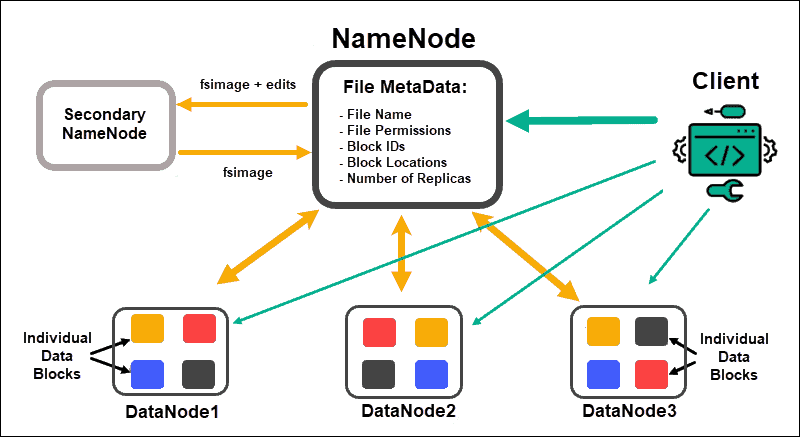

Obrázek převzat ze zdroje:https://phoenixnap.com/kb/apache-hadoop-architecture-explained

Pro práci s HDFS budeme v dalším používat skript *hdfs*, který nám umožní provádět běžné operace nad souborovým systémem tak, jak je známe z prostředí systému linux.

Syntaxe je následující

```
hdfs PRIKAZ [-volby]
```

Pro běžnou práci se soubory budeme používat příkaz *dfs*

Tedy pokud chcem například vypsat obsah *rootu*, tak použijeme:

```
hdfs dfs -ls /
```

Pro vytvoření adresáře *userdata* v rootu:

```
hdfs dfs -mkdir /userdata
```

Pro vykopírováni dat do HDFS použijeme příkaz *put*. Tedy nakopírování lokálního souboru na cestě */home/Petr/data/soubor.txt* do HDFS */userdata* provedeme:

```
hdfs dfs -put /home/Petr/data/soubor.txt /userdata
```

Podobně v otočeném gardu použijeme příkaz *cat*, který čte data a posílá je na standardní výstup, [stdout](https://cs.wikipedia.org/wiki/Standardn%C3%AD_proudy).

Další příkazy pro práce se soubory pomocí [dfs](https://hadoop.apache.org/docs/stable/hadoop-project-dist/hadoop-common/FileSystemShell.html).

Příkaz *dfs* není jediným příkazem, pomocí kterého můžeme ovládat HDFS. Jsou zde různé příkazy pro roli administrátora, který musí zpravovat celý kluster, např. kontrola filesystému, balancování uzlů apod. Přehled je uveden [zde](https://hadoop.apache.org/docs/stable/hadoop-project-dist/hadoop-hdfs/HDFSCommands.html).

## Zprovoznění Hadoop

Pro naše použití této technologie budeme používat jeho dockerizovanou verzi, která je ke stažení [zde](https://github.com/big-data-europe/docker-hadoop). V dalším předpokládám, že máte k dispozici linuxový stroj.

Nejprve si vytvoříme lokální adresář:

```
mkdir hadoopdocker
```

poté z výše uvedeného odkazu na [git](https://github.com/big-data-europe/docker-hadoop) stáhneme celý repozitář a ve vytvořeném adresáři jej rozbalíme. Vznikne tím v něm adresář *docker-hadoop-master*, který již obsahuje potřebnou inrastrkuturu pro docker. Pomocí příkazu *cd* do něj vstoupíme:

```
cd hadoopdocker/docker-hadoop-master
```

Poté spustíme *docker*, musíme jej ovšem mít nainstalovaný na daném stroji, viz instalace [zde](https://docs.docker.com/get-docker/):

```
docker-compose up
```

Instalace všech potřebných náležitostí chvilku trvá. Při dalším spuštění stačí už jen provést poslední příkaz. Pokud chceme zastavit, tak příkaz:

```
docker-compose down
```

Ověření startu dockeru zajistíme pomocí:

```
docker ps
```

uvidíme pak, jednotlivé běžící komponenty ekosystému.

### Ověření běhu dockerizovaného Hadoopu

Je možné ověřit běh jednotlivých komponent systému. Lze použít buď postup udávaný [zde](https://www.section.io/engineering-education/set-up-containerize-and-test-a-single-hadoop-cluster-using-docker-and-docker-compose/). Nebo nejprve spustíme daný kontajner, viz výše. A do dalšího okna terminálu v adresáři příslušného kontajneru, v našem případě v *hadoopdocker/docker-hadoop-master*, napíšeme

```
docker network inspect docker-hadoop-master_default
```

Obdržíme následující výstup. Kde jsou vidět jednotlivé *ipadresy* dockerizovaných uzlů clusteru.

### Výstup inspekce

```
[
    {
        "Name": "docker-hadoop-master_default",
        "Id": "fb2d1635f79ee60e325568f61b4597bdc9669b0c206212ae6bac349c93550cc8",
        "Created": "2022-05-24T12:32:18.883154551+02:00",
        "Scope": "local",
        "Driver": "bridge",
        "EnableIPv6": false,
        "IPAM": {
            "Driver": "default",
            "Options": null,
            "Config": [
                {
                    "Subnet": "172.21.0.0/16",
                    "Gateway": "172.21.0.1"
                }
            ]
        },
        "Internal": false,
        "Attachable": true,
        "Ingress": false,
        "ConfigFrom": {
            "Network": ""
        },
        "ConfigOnly": false,
        "Containers": {
            "2b5295b820e17eedb8f98c70d146b428ff95105c5ae951bc41c83475a79fc9f3": {
                "Name": "namenode",
                "EndpointID": "04ad3f6bcad34a9aaac892fc6b63448a15dc1f52eb0febadbb7bc7421678938d",
                "MacAddress": "02:42:ac:15:00:02",
                "IPv4Address": "172.21.0.2/16",
                "IPv6Address": ""
            },
            "47dfec0900648b7460821af1e29bc30cf62ae5eb317c91fcde80fc44dccb4c6d": {
                "Name": "nodemanager",
                "EndpointID": "a5e03d23760b5c31668dbb5876bb0b9c4fea6b689a72f8d6b76ba39145efd5fa",
                "MacAddress": "02:42:ac:15:00:05",
                "IPv4Address": "172.21.0.5/16",
                "IPv6Address": ""
            },
            "69e8cb0f28cd7d49f89d2bc2026d38609b50507c654ea2d5457a3cd16226717e": {
                "Name": "datanode",
                "EndpointID": "bb6b4212ebceab24ba302dee297d211fd3019a64cabd106307088d93f3165c2c",
                "MacAddress": "02:42:ac:15:00:06",
                "IPv4Address": "172.21.0.6/16",
                "IPv6Address": ""
            },
            "9806f318a018bd7770072e9737106e6679d226aaab8b0504c6c940aa784d8e64": {
                "Name": "historyserver",
                "EndpointID": "1860dc540733226af9853d0a966ebc8028ab7b2251ed7a10690ec6d6359b187a",
                "MacAddress": "02:42:ac:15:00:04",
                "IPv4Address": "172.21.0.4/16",
                "IPv6Address": ""
            },
            "cc8e4827185bc24e934d67350231baab749def2762cd7ce7b0d683320f146f07": {
                "Name": "resourcemanager",
                "EndpointID": "b311317528c4fe2a2b1d52c0c2d9ca6ff40803317085329e104a5f0613e1daf5",
                "MacAddress": "02:42:ac:15:00:03",
                "IPv4Address": "172.21.0.3/16",
                "IPv6Address": ""
            }
        },
        "Options": {},
        "Labels": {
            "com.docker.compose.network": "default",
            "com.docker.compose.project": "docker-hadoop-master",
            "com.docker.compose.version": "1.25.0"
        }
    }
]
```

K uvedeným uzlům, lze přistupovat pomocí uvedené adresy a portu v prohlížeči. Jednotlivé porty [dle](https://www.section.io/engineering-education/set-up-containerize-and-test-a-single-hadoop-cluster-using-docker-and-docker-compose/) jsou:

- datanode - port 9864
- nodemanager - port 8042
- namenode - port 9870
- historyserver - port 8188
- resourcemanager - port 8088

Napíšeme - li do adresního řádku prihlížeče (ipadresa, viz výše)

```
http://172.21.0.2:9870/
```

tak se dostaneme k webovému rozhraní *namenodu*. K ostatním uzlům je to podobné.

### Spouštění příkazů

Opět předpokládáme, že je spuštěný daný kontajner, a že se nacházíme v něm. V příkazové řádce si spustíme interaktivní shell běžící na *namenodu*:

```
docker exec -it namenode /bin/bash
```

```
hdfs dfs -ls /
```

a obdržíme něco podobného:

```
Found 1 items
drwxr-xr-x   - root supergroup          0 2022-05-04 10:56 /rmstate
```

Nyní si vytvoříme adresář, do kterého budeme nahrávat soubory pro zpracování. Abychom dodrželi nějakou štábní kulturu (zjednodušuje se tím odkazovíní souborů), tak si pro uživatele *root* vytvoříme v adresáři *user* vlastní adresář (*root*) a v něm další adresář pro data (*data*). Protože jsme líní, tak to uděláme v jednom řádku, za použití přepínače *p*:

```
hdfs dfs -mkdir -p /user/root/data
```

V shellu můžeme vytvořit domovský adresář na HDFS systému (je to nutné pro další zpracování).

A pro jistoti ověříme.

```
hdfs dfs -ls
```

(místo `hdfs dfs` lze využít `hadoop fs`).

Do lokálního systému kontejneru stáhneme ukázkový soubor (i když je *Vojna a mír* pověstná bichle, zdaleka nezaplní ani jeden blok HDFS).

`curl https://www.gutenberg.org/files/2600/2600-0.txt > war_and_peace.txt`

`hdfs dfs -put ./war_and_peace.txt /user/root`

> **Úkol**: Prozkoumejte a popřípadě vyzkoušejte další příkazy HDFS. (např. zde https://www.geeksforgeeks.org/hdfs-commands/)

## Map-Reduce

Základní mechanismus Hadoopu je implementace distribuovaného zpracování typu map a reduce. Detailní popis celého mechanismu je v *Big Data a NoSQL databáze* (včetně příkladu jeho využití v jazyce Java).

Zde tedy jen stručně:

Funkce `Map` slouží ke zpracování každého objektu z množiny vstupních dat (v tectovém vstupu je to typicky řádek) a jejím výstupem je jedna nebo více dvojic (klíč, hodnota) pro každý zpracovaný objekt.

Funkce `Reduce` slouží ke sloučení výsledků (hodnot) pro jednotlivé klíče z předchozí fáze do celkového výsledku.

Funkce `Map` realizuje funkcionál `map` (https://en.wikipedia.org/wiki/Map_(higher-order_function)) a `Reduce` funkcionál `fold` (https://en.wikipedia.org/wiki/Fold_(higher-order_function)). Ty jsou všeobecně užívané a to nikoliv jen ve funkcionálním programování. Hadoop však (při běžném nasazení) přináší masívní paralelismus.

obecný tvar funkcí:

Map: $K_1 \times H_2 \rightarrow K_2 \times H_2$, kde $K_1$, $K_2$ jsou množiny klíčů a $H_1$, $H_2$ množiny hodnot

Reduce: $(K_2, P(H_2)) \rightarrow (K_2, P(H_2)$, kde druhý člen dvojice je neuspořádaná množina všech hodnot, které vrátila mapovací fáze s určitým klíčem (tj. prvek potenční množiny).

Mezi oběma fázemi je nutno (distribuovaně) seskupit hodnoty se stejným klíčem, což je běžně zajištěno setříděním.

Graficky si lze základní kroky znázornít například takto:

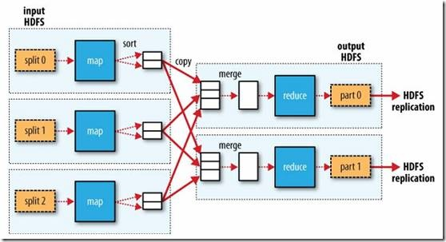

Výše uvedené kroky jsou základní (ovlivnit lze i další pomocné) a lze je přirozeně provádět i opakovaně.

## Hadoop streaming

Hadoop přímo podporuje jen jediné vývojové prostředí — standardní Java SDK. Lze však využít tzv. *Hodoop streaming*, kdy jsou jednotlivé fáze (tj. minimálně mapovací a redukční) vykonávány libovolným programem očekávající vstupní data na standardní vstupu a produkujícím výstup na standardní.

Distribuovaný program je tak možno napsat v téměř libovolném vývojovém prostředí včetně např. shellu. Zvlášť snadné je použití skriptovacích jazyků např. Pythonu. Je však třeba si uvědomit, že toto řešení není dokonalé, neboť vyžaduje instalaci běhových prostředí na všech uzlech (tj. například Pythonu). Není také nijak zvlášť efektivní neboť přináší dodatečnou režii se spuštěním jednotlivých procesů a vytvářením síťových socketů, které je spojují.

To značně komplikuje použití výše uvedené dockerizované verze Hadoopu, jenž obsahuje pouze základní linuxové nástroje (založení na minimální instalaci Ubuntu). Použít lze pouze shell skripty, které moho využívaj jen základní aplikace. Pythho není k dispozici vůbec. Z tohoto důvodu je nutné dodat Python do některých Docker obrazů:

1. do YARNu (správce prostředků)
2. do workerů (`nodemanager`)

Rozšířený Dockerfile pro pracovní uzel má následující tvar (obrazy jsou založeny na Debian Linuxu, a instalována je i knihovna `mrjob` využívaná v následující sekci):

```
FROM bde2020/hadoop-nodemanager:2.0.0-hadoop3.2.1-java8

RUN apt-get update && apt-get install -y python3 python3-pip
RUN pip3 install mrjob
```

Podobně je změněn i obraz pro správce prostředků.

> **Úkol**: Proveďte změny a modifikujte i yaml soubor pro vytváření kompozitního kontejneru.

Nyní připravíme dva skripty, které busdsou řešit klasický ukázkový příklad pro Hadoop — zjištění počtu výskytů jednotlivých slov (resp. jejich tvarů) v textovém souboru.

První provádí mapování. Vstup můžeme interpretovat jako jedinou hodnotu (s prázdným klíčem) a je předán na standardním vstupem. Výstupem je množina dvojic klíč, hodnota, kde jednotlivé dvojice tvoří řádky (oddělovačem je tudíž odřádkování). Klíč je pak od hodnoty oddělen tabulátorem (což je pro Hadoop streaming standardní oddělovač).

```python
%%writefile mapper.py
#!/usr/bin/env python3
import sys

for line in sys.stdin: # v každém řádku
    words = line.split() # rozdělení na slova

    for word in words: # pro každé slovo
        print(f'{word}\t{1}') # vrací dvojici (slovo, 1)
```

```
Overwriting mapper.py
```

Redukční skript je o něco komplexnější. Přijímá dvojice od mapperu a vrací součet hodnot. Protože každý výskyt slova je doprovázen hodnotou získáme jejich součtem celkový počet výskytů. Přitom se předokládá, že:

- hodnoty pro každý jednotlivý klíč jsou zpracovány právě jedním uzlem `worker` (není nutné vytvářet součty součtů)
- vstuoní dvojice jsou sařazené podle klíčů (tj. tvoří souvislou posloupnost řádků).

Výstupem je dvojice, kde klíčem je opět slovo a hodnotou součet (obecně to může být i množina hodnot, v tomto případě je tudíž jednoprvková).

```python
%%writefile reducer.py
#!/usr/bin/env python3
import sys

curr_word = None
curr_count = 0


for line in sys.stdin:
    word, count = line.split('\t')
    count = int(count)

    if word == curr_word: # slovo je
        curr_count += count
    else:
        if curr_word:
            print(f'{curr_word}\t{curr_count}')
        curr_word = word

if curr_word == word: # pro poslední slovo
    print(f'{curr_word}\t{curr_count}')
```

```
Overwriting reducer.py
```

`docker exec -it namenode /bin/bash`

Nejdříve oba soubory označíme jako spustitelné.

`# chmod a+x mapper.py reducer.py`

Pak vyzkoušíme jak fungují lokálně (tj. nedistribuovaně), soubor `war_and_peace.txt` musí být v lokálním adresáři.

`cat war_and_peace.txt | ./mapper.py | sort -t 1 | ./reducer.py`

A nyní už můžeme spustit distribuované zpracování (proměnná shellu `HADOOP_HOME` musí obsahovat adresář hadoopu v lokálním souborovém systému kontejneru). Vstupní soubor musí být umístěn v HDFS v domovském adresáři uživatele.

```
$HADOOP_HOME/bin/hadoop jar
$HADOOP_HOME/mapred/contrib/streaming/hadoop-streaming*.jar \
-files mapper.py,reducer.py \
-mapper mapper.py \
-reducer reducer.py \
-input /user/root/war_and_peace.txt -output /user/hduser/histogram.txt
```

> **Úkol**: Toto řešení je neefektivní, neboť mapper nemusí vracet dvojici pro každý výskyt slova (s hodnotou jedna), ale vždy jen jednu dvojici pro každéí slovo, které najde ve svém fragmentu vstupního souboru (hodnotou je jeho počet) tj. lokální histogram. Vytvořte tento efektivnější mapper (např, za pomoci kolekce `colections.Counter`).

Rozdělení na dva skripty je nepřehledné a program nevyužívá žádný z typických konstrukcí Pythonu (není například objektový). Řešením je použití knihovny `mrjob`, která využívá Hadoop streaming, ale nabízí pythoničtější rozhraní.

# 4. MRJOB

## Co se naučíte?

- seznámíte se s knihovnou MRJOB
- vyzkoušíte ladící režim (nevyžaduje Hadoop)
- spustíte MRJOB v dokerizovaném Hadoopu

[MRJob](https://mrjob.readthedocs.io/en/latest/index.html#) je knihovna pro Python, která nám umožňuje snadno psát úlohy typu *Map* a *Reduce*. Její výhodou je poměrně slušná dokumentace a hlavně zde odpadá nutnost mít nainstalovaný *Hadoop*, protože je možné ji spouštět i lokálně. Z mého pohledu jako plus hodnotím i to, že je použit objektový přístup a uživatel si pouze podědí od bázové třídy a doplní příslušné metody.

**Poznámka**

Pro otestování uvedených příkladů stačí překopírovat buňky do pythonovského souboru a pak normálně spouštět z příkazové řádky.

## Map Reduce - Hello World

Téměř ve všech materiálech věnovaných Map a Reduce (*MR*), je ukázáno počítání počtu slov v nějakém dokumentu. Pojďme si na této úloze ilustrovat danou knihovnu *MRJob*.

Na ukázce níže je zmiňovaná implementace počítání počtu slov. Nejprve je vytvořena třída, která dědí od *MRJob*, pak už stačí jen redefinovat metody *mapper* a *reducer*. Metoda *mapper* slouží k tomu, že přijímá textová data a provádí na nich transformaci tak, že získáme dvojici *klíč* a *hodnota*. V "našem" příkladu je vždy vytvořena dvojice slovo a číslo jedna. Metodou *reduce* právě provádíme operace nad hodnotami příslušejícími daným klíčům. Tedy *reducer* dostává ke každému klíči **generátor** hodnot. V níže uvedeném příkladu jsou pak sečteny všechny hodnoty, tedy všechny jedničky a dostáváme počet výskytů daného slova. V tomto minimalistickém příkladu bylo vynechána metoda *combiner*, která slouží ke slučování výsledků přicházejících z *mapperu*.

Poslední částí je pak zavolání metody *run* pro spuštění.

```python
from mrjob.job import MRJob

class WordCounter(MRJob):
	def mapper(self, _, line):
		for word in line.split():
			yield(word, 1)
	def reducer(self, word, counts):
		yield(word, sum(counts))

if __name__ == '__main__':
	WordCounter.run()
```

V dalším předpokládám, že program se jmenuje *wc.py* a spustíme jej v terminálu příkazem, kde *data.txt* je soubor, který chceme zpracovávat. Výstup bude produkován na standardní výstup *STDOUT*.

```
python3 wc.py -r inline data.txt
```

**Poznámka**

Parametry příkazové řádky nám umožňují spouštět MRJob ve více módech. Pro nás nejzajímavější jsou *inline*, který je spouštěn v jednom procesu a je určen pro testování, zároveň je defaultní volbou, více viz [zde](https://mrjob.readthedocs.io/en/latest/runners-inline.html). Druhá volba je *local*, zde je již využito spuštění na více procesech, více viz [zde](https://mrjob.readthedocs.io/en/latest/runners-local.html).

## Map Reduce - Četnosti slov

Nyní si ukážeme mírně komplikovanější úlohu. Program určí *n* slov s největší četností a pak nakreslí jejich historgram. Nejprve se podívejme na určování četností. Pro určení četností je nutné udělat více průchodů, tedy více operací map a reduce. Každý průchod map, combine, reduce se nazývá *step* (stupeň), viz [MRStep](https://mrjob.readthedocs.io/en/latest/step.html?highlight=mrstep) a výstupy jednotlivých stupňů jsou takto skládány. Napojení těchto stupňů se odehrává v metodě *steps*.

Na ukázce níže jsou použity dva stupně, kde první stupeň používá všechny tři metody map, combine, reduce a druhý jen reduce. V mapperu prvního stupně (*mapper_map_words*) jsou jednotlivé řádky parsovány pomocí regulárních výrazů, viz [zde](https://docs.python.org/3/library/re.html), a každému slovu je přiřazena jednička. Jednotlivých instancí mapperů může obecně být více a každý bude zpracovávat část úlohy, proto se obvykle nad nimi píše metoda combine (*combiner*), která výsledky skládá a posílá dále. Vede to často ke zmenšení objemu přenášených dat. V naší ukázce v kombineru sčítáme počet výskytů nad daným slovem. První step je ukončen operací reduce, kde jsou opět sčítány výskyty slov, tedy výsledky z combine a následně je vytvořen generátor, který **nevrací klíč**, viz *None* na dané pozici a jako příslušná hodnota je použita dvojice slovo a četnost.

**Poznámka**

Lze to udělat i tak, že budeme vracet dvojici slovo a počet výskytů. Jako **samostatný úkol** upravte daný kód. Pozor, bude nutné upravit i reducer ve druhém stupni.

Druhý stupeň je tvořen samostatným reducerem, který už jen výsledky setřídí a propustí deset nejčetnějších slov.

```python
# import knihoven a nastaveni
from mrjob.job import MRJob
from mrjob.step import MRStep
import re

rex = re.compile(r"\b[\w']{2,}") # vytvoreni regularniho vyrazu, chci slova delsi nez dva znaky
nth = 10 # kolik nejcastejsich slov
```

```python
# vlastni implementace úlohy
class Count(MRJob):
    def mapper_map_words(self,_, line):
        for word in rex.findall(line):
                yield (word.lower(), 1)
    def combiner_combine_words_count(self, word, counts):
        yield (word, sum(counts))
    def reducer_count_words(self, word, counts):
        yield None, (sum(counts), word)
    def reducer_max_word(self,_,count_word_pair):
        for count, word in sorted(count_word_pair, reverse=True)[:nth]:
            yield (word, count)
    def steps(self):
        return [
            MRStep(mapper=self.mapper_map_words,
                   combiner=self.combiner_combine_words_count,
                   reducer=self.reducer_count_words),
            MRStep(reducer=self.reducer_max_word)
        ]

if __name__ =='__main__':
    Count.run()
```

Pro otestování jsme si stáhněte například román [RUR](https://www.gutenberg.org/ebooks/59112) a uložili jej jako *rur.txt*. Za předpokladu, že program se jmenuje *wordhistogram.py* jej spustíme následujícím kódem. Všimněte si přesměrování výsledků do souboru (*>*) *wordresults.txt*.

```
python3 wordhistogram.py -r local rur.txt > wordresults.txt
```

Dále je již jen vykreslení výsledků z daného souboru.

```python
import pandas as pd
import matplotlib.pyplot as plt

if __name__=="__main__":
    data = pd.read_csv("wordresults.txt", sep="\t", header=None, index_col=0)
    print(data.head())
    ax = data.plot.bar(legend='')
    plt.xticks(rotation = 45)
    plt.title("Cetnosti slov")
    plt.show()
```

## Map Reduce - Průměrná teplota

Nyní si ukážeme mírně komplikovanější úlohu, kde budeme číst ze vstupního *csv* souboru údaje o počasí, budeme počítat dení průměry a určíme počet dní v měsíci, kdy byla teplota vyšší než daná hodnota. Předpokládáme data v csv formátu, viz tento [soubor](https://1url.cz/@jf_meteo), který si ovšem musíte rozbalit.

Výše zmíněná komplikace spočívá v tom, že nepočítáme průměry za celý den, ale jen pro nějaké pevně stanovené časy v 7, 14 a 21 hodin. Další komplikace spočívá v tom, že operací map může být spušteno více a není možné počítat průměr přímo v kombineru nad touto operací a pak ještě v reduceru, neboť by to počítalo průměr průměrů.

V kódu níže je jedno z možných řešení. Opět jsou použity dva stupně. V prvním stupni se pracuje na úrovni dnů. Nejprve dojde, v operaci map (*mapper_map_day_temperature*) k naparsování info o počasí a filtrování hodnot na příslušné časy. Nakonec je vytvořen generátor, kde klíč je pouze datum (den) a hodnota je teplota ve stanovenou hodnotu. V následném combineru (*combiner_combine_temp*) je pro každý den vracena dvojice součet teplot a počet sečtených hodnot. Reducer prvního stupně (*reducer_filter_temperature*) opět přijímá tyto údaje a už počítá celkový průměr teploty v daném dni. Pokud je teplota vyšší než zadaná teplota (*temperature_filter*) přiřadí k danému dni hodnotu jedna, v opačném případě nula, čímž dochází k filtrování hodnot.

Druhý stupeň pouze počítá počet dnů průměrnou teplotou vyšší než je zadaná teplota. Je to analogické určení počtu slov. Jediné co je třeba udělat je převádět klíče z formátu dnů na měsíce.

```python
from mrjob.job import MRJob
from mrjob.step import MRStep
from _datetime import datetime

header_line = "datetime"
datetime_index = 0
outtemp_index = 3

selected_hours = set([7, 14, 21])
temperature_filter = 20.0


class Count(MRJob):

    def mapper_map_day_temperature(self, _, line):
        items = line.split(',')
        if items[datetime_index] != 'datetime':  # preskoc prvni radek
            date = datetime.strptime(items[datetime_index], '%Y-%m-%d %H:%M:%S')
            if date.hour in selected_hours and date.minute == 0:
                yield (f"{date.date()}", float(items[outtemp_index]))  # date.date() float(items[2])

    def combiner_combine_temp(self, day, temperatures):
        suma = 0
        counter = 0
        for value in temperatures:
            suma += value
            counter += 1
        yield (day, (suma, counter))

    def reducer_filter_temperature(self, day, val):
        c = 0
        total = 0
        for s, n in val:
            c += n
            total += s
        # zda ma prumernou teplotu - za vsechna mereni
        if total/c >= temperature_filter:
            yield  (day, 1) #(day, f"{total / c}-->{1}")
        else:
            yield (day, 0) #(day, f"{total / c}-->{0}")

    def mapper_map_day_to_month(self, day, val):
        yield (day[:7], val)

    def combiner_sum_days(self, month, val):
        yield (month, sum(val))

    def reducer_sum_days(self, month, val):
        yield (month, sum(val))

    def steps(self):
        return [
            MRStep(mapper=self.mapper_map_day_temperature,
                   combiner=self.combiner_combine_temp,
                   reducer=self.reducer_filter_temperature),
            MRStep(mapper=self.mapper_map_day_to_month,
                   combiner=self.combiner_sum_days,
                   reducer=self.reducer_sum_days)

        ]


if __name__ == '__main__':
    Count.run()
```

Za předpodkladu, že stažený soubor se jmenuje *meteo.csv* a daný skript *weather.py* spustíme z příkazové řádky následovně:

```
 python3 weather.py -r local meteo.csv
```

## Distribuované spuštění

Pro distribuované prostředí je potřeba mít nakonfigurováno prostředí pro Hadoop streaming (tj. skript musí být spustitelný na všech uzlech) včetně dostupnosti `mrjob` a vstupní data musí být v HDFS.

Vlastní spuštění je pak už snadné.

`python3 weather.py -r hadoop hdfs://user/root/meteo.csv`

> **Úkoly**: Vyzkoušejte distribované zpracování a porovnejte jeho efektivitu s lokálním řešením (zohledněte to, že v případě využití docker verze je zpracování de facto stále lokální)

# 5. Apache Spark

## Co se naučíte?

- instalaci dockerizovaného Sparku
- seznámíte se základní datovou abstrakcí (RDD — *resilient distributed data set*)
- prozkoumáte možnosti nízkoúrovňových operací nad RDD

## Co je Spark

I když se přístup, který zavedl Hadoop ukázal jako podnětný, přináší i jistá omezení:

- data (a to i mezivýsledky) jsou ukládány do HDFS, který sice nabízí robustnost, ale i vyšší režii (ta se pro jevuje především při zpracování dat)
- základní model MapReduce není příliš flexibilní a nelte jej aplikovat na některé třídy problémů
- Java je jediný jazyk, který je v Hadoopu nativně podporován, ostatní jazyky musí využívat jen nepříliš elegantní proudové rozhraní
- obtížné ladění programů (nelze je ladit bez minimálně tří běžících služeb)

Z tohoto důvodu vzniklo několik řešení, které se při zachování výhod Hadoopu (distribuovanost dat i výpočtů) snaží nabídnout efektivnější a flexibilnější model.

Spark patří mezi ty nejambicioznější, neboť poskytuje vysokoúrovňovou platformu s podporou několika programovacích jazyků, několika API a vlastní implementací výpočetního clusteru (tj. bez závislosti na Hadoopu).

Základní charakteristikou Sparku je distribuované ukládání mezivýsledků do operační paměti. Tyto tzv. *resilient distributed dataset* jsou při zachování odolnosti proti výpadkům mnohem efektivnější než HDFS soubory. Na druhou stranu jej jejich velikost omezena na gigabyty (nejsou tak vhodné pro opravdu enormní datové sady).

## Instalace

Programy napsané pro Apache Spark lze vykonávat i bez instalace distribuovaného prostředí, neboť Apache Spark lze provozovat ve třech základních režimech:

1. lokálně = pracovní uzly běží jako lokální procesy
2. prostřednictvím samostatného Spark (v tomto případě je již nutné zajistit distribuci dat a Pythonského prostředí)
3. prostřednictvím Hadoop správce zdrojů a plánovače Yarn (a s vyuužití HDFS pro sdílení dat i kódu)

Lokální běh sice neumožňuje využít sílu distribuovaného zpracování, hodí se však pro účely ladění.

Nejjednodušším krokem je instalace klintská části. My zvolíme *pyspark* (další možností jsou klienti pro Scalu a R). Ten se instaluje jako běžný pythonský framework např. prostřednictvím `pip`.

```python
!pip install pyspark
```

Instalací se kromě příslušných modulů nainstaluje i interaktivní (REPL) prostředí `pyspark`. Spusťte ho a tím ověříte, že klient je dobře nainstalován.

Po spuštění můžete také zkontrolovat jaký režim je právě využíván:

```
Welcome to
      ____              __
     / __/__  ___ _____/ /__
    _\ \/ _ \/ _ `/ __/  '_/
   /__ / .__/\_,_/_/ /_/\_\   version 3.2.1
      /_/

Using Python version 3.9.7 (default, Oct 27 2021 01:23:21)
Spark context Web UI available at http://192.168.122.1:4040
Spark context available as 'sc' (master = local[*], app id = local-1652515703360).
SparkSession available as 'spark'.
>>>
```

V tomto případě je aktivní režim `locaĺ[*]` tj. běh v několika souběžných lokálních procesech.

Pokud chcete vyzkoušet distribuované prostředí (i když de facto stále omezené na jednoho hostitele) použijte docker obraz na adrese https://github.com/big-data-europe/docker-spark.

> **Úkol**: Nainstalujte si tento obraz a prostudujte dokumentaci, jak ho používat.

Pro spuštění můžete využít následující zjednodušenou `docker-compose` konfiguraci:

```
ersion: '3'
services:
  spark-master:
    image: bde2020/spark-master:3.2.0-hadoop3.2
    container_name: spark-master
    ports:
      - "8080:8080"
      - "7077:7077"
    environment:
      - INIT_DAEMON_STEP=setup_spark
  spark-worker-1:
    image: bde2020/spark-worker:3.2.0-hadoop3.2
    container_name: spark-worker-1
    depends_on:
      - spark-master
    ports:
      - "8081:8081"
    environment:
      - "SPARK_MASTER=spark://spark-master:7077"
```

Obecně vždy potřebujete službu master a alespoň jednu službu `worker`.

Po spuštění se zkuste z `pyspark` připojit k serveru `master` (IP adresa se může měnit, použijte `docker network inspect docker-spark_default` pro její zjištění).

```
pyspark --master "spark://172.20.0.2:7077"
```

Jak master tak worker zobrazují stav na na URL `http://localhost:8080` resp. `http://localhost:8081` (podívejte se na ně).

> **Úkol**: Přidejte další worker uzel v `docker-compose.yml`. Nezapomeňte změnit externí port, aby se nepřekrýval s prvním uzlem (např. na 8082). S touto konfigurací bude nadále pracovat.

pro ty, kterým to připadá triviální:

```
dmVyc2lvbjogJzMnCnNlcnZpY2VzOgogIHNwYXJrLW1hc3RlcjoKICAgIGltYWdlOiBiZGUyMDIw
L3NwYXJrLW1hc3RlcjozLjIuMC1oYWRvb3AzLjIKICAgIGNvbnRhaW5lcl9uYW1lOiBzcGFyay1t
YXN0ZXIKICAgIHBvcnRzOgogICAgICAtICI4MDgwOjgwODAiCiAgICAgIC0gIjcwNzc6NzA3NyIK
ICAgIGVudmlyb25tZW50OgogICAgICAtIElOSVRfREFFTU9OX1NURVA9c2V0dXBfc3BhcmsKICBz
cGFyay13b3JrZXItMToKICAgIGltYWdlOiBiZGUyMDIwL3NwYXJrLXdvcmtlcjozLjIuMC1oYWRv
b3AzLjIKICAgIGNvbnRhaW5lcl9uYW1lOiBzcGFyay13b3JrZXItMQogICAgZGVwZW5kc19vbjoK
ICAgICAgLSBzcGFyay1tYXN0ZXIKICAgIHBvcnRzOgogICAgICAtICI4MDgxOjgwODEiCiAgICBl
bnZpcm9ubWVudDoKICAgICAgLSAiU1BBUktfTUFTVEVSPXNwYXJrOi8vc3BhcmstbWFzdGVyOjcw
NzciCiAgc3Bhcmstd29ya2VyLTI6CiAgICBpbWFnZTogYmRlMjAyMC9zcGFyay13b3JrZXI6My4y
LjAtaGFkb29wMy4yCiAgICBjb250YWluZXJfbmFtZTogc3Bhcmstd29ya2VyLTIKICAgIGRlcGVu
ZHNfb246CiAgICAgIC0gc3BhcmstbWFzdGVyCiAgICBwb3J0czoKICAgICAgLSAiODA4Mjo4MDgx
IgogICAgZW52aXJvbm1lbnQ6CiAgICAgIC0gIlNQQVJLX01BU1RFUj1zcGFyazovL3NwYXJrLW1h
c3Rlcjo3MDc3Igo=
```

Nyní už můžeme vytvářet první programy pro Spark. Začneme klíčovou abstrakcí frameworku Spark.

## Resilient distributed dataset

Na nejnižší úrovni programování se ve Sparku pracuje s *resilient distributed datasets*:

1) jsou to datové sady = posloupnosti n-tic (tj. de facto tabulky) včetně posloupnosti řetězců (řádků) a posloupnosti bloků bytů (podporovány jsou elementární typy i komplexní objekty podporovaných jazyků, lze ) 2) jsou distribuované na jednotlivé uzly (po částech, tzv. *partitioning*, k dispozici je ale i replikace) 3) jsou odolné proti závadám na jednotlivých uzlech (fault tolerant)

mezi další vlastnosti patří:

- neměnnost (aplikací mapovací operace vznikne nové RDD)
- úložištěm je primárně operační paměť (v případě většího objemu dat, či požadavku presistentního kešování však mouho být uložena i v distrubuovaném FS)
- mapovací operace nad RDD jsou lenivé (provedou se až tehdy, kdy je očekáván výsledek)

RDD mohou vzniknout dvěma způsoby:

- paralelizací existujícího kontejneru (v Pythonu typicky seznamu nebo numpy pole)
- čtením ze souboru (typicky ze diatribuovaného souborového systému HDFS).

```python
from pyspark import SparkContext, SparkConf
import numpy as np

conf = SparkConf().setAppName("test").setMaster("local")
with  SparkContext(conf=conf) as sc:
    data = np.arange(0, 10_000, dtype=np.int16) #list(range(1_000))
    print(type(data))
    rdd = sc.parallelize(data, 8) # objekt representuje rozddistribuované RDD
    print(type(rdd))
    cdata = rdd.collect()
    print(cdata[:100]) # vypíšeme jen prvních sto položek
    print(type(cdata)) # cdate je seznam
```

[output not shown]

Jádrem programu je vytvoření tzv. spark-kontextu. Ten je vytvořen na základě konfigurace, která v tomto případě uvádí jen jméno úlohy (*job*) a režim vykonávání. Jméno úlohy se zobrazuje v případě použití distribuovaného systému a režim je v tomto případě jen lokální (spuštění ve Spark clusteru si necháme na zajímavější program).

RDD vznikne paralelizací numpy pole (je možné využít i seznam či jinou sekvenci = indexovatelnou kolekci) metodou nad objektem kontextu. Další metody se volají již přímo nad RDD objektem. Zde je použita metoda `collect`, která shromáždí data RDD ze všech výpočetních uzlů.

Context je nutno ukončit a uvolnit, což v tomto případě zajišťuje konstrukce `with`.

Reálnější (i když datově opět neadekvátně malý) ukazuje jednoduché zpracování CSV souboru.

```python
%%writefile data.txt

2022-05-12,10,3
2022-05-13,8,2
2022-05-14,11,1
2022-05-15,14,-3
```

```
Writing data.txt
```

```python
from pyspark import SparkContext, SparkConf
from operator import add

conf = SparkConf().setAppName("test").setMaster("local")
with  SparkContext(conf=conf) as sc:
    rdd = sc.textFile("data.txt")
    t_rdd = rdd.filter(lambda line: line.strip()).map(lambda line: int(line.split(",")[2]))
    result = t_rdd.reduce(add) # redukujeme součtem
    print(result)
```

```
3
```

Nejdříve se provede vytvoření RDD ze souboru. To se nicméně prozatím neprovede , jen se naplánuje. V dalším kroku se provedou dvě **transformace**. První odfiltruje prázdné řádky, druhá je rozloží a vrátí třetí sloupec jako číslo. Všechny transformace jsou lenivé a tak ani na tomto řádku se nic neprovede.

Posledním krokem je redukce operací `add` (= obdoba operátoru `+` v podobě funkce). To je **akce**, která způsobí vykonání všech transformací a vstupních metod na nichž závisí (kromě různých typů redukcí do akcí patří i metoda `collect`.

> **Úkol**: Upravte kód tak, aby počítal průměr. (existuje několik řešení). Nabídku možných transformací najdete na například na https://spark.apache.org/docs/latest/rdd-programming-guide.html.

Spuštění ve dockerizovaném Spark clusteru, který se víc blíží konečnému nasazení (i když stále není možné mluvit o nějakém skutečně distribuovaném zpracování) není přímočaré.

```python
%%writefile app.py

from pyspark import SparkContext, SparkConf
from operator import add

conf = SparkConf().setAppName("test")
with  SparkContext(conf=conf) as sc:
    rdd = sc.textFile("/app/app.py")
    t_rdd = rdd.filter(lambda line: line.strip()).map(lambda line: int(line.split(",")[2]))
    result = t_rdd.reduce(add) # redukujeme součtem
    print(result)
```

```
Overwriting app.py
```

V dalším kroku je nutné v témže adresáři vytvořit Dockerfile odvozený z bde2020/spark-python-template. (dokumentace viz popis šablony na githubu).

```
FROM bde2020/spark-python-template:3.2.0-hadoop3.2

ENV SPARK_APPLICATION_PYTHON_LOCATION /app/app.py
```

Dále je nutné v tomto adresáři vytvořit soubor `requirements.txt` se jmény nestandardních modulů, jež je nutno nainstalovat přes `pip` (musí být vytvořen i když zůstane prázdný).

Ten poté přeložit:

```
docker build --rm -t bde/spark-app .
```

A spustit:

```
docker run --rm --name my-spark-app -e ENABLE_INIT_DAEMON=false --link spark-master:spark-master
           --net docker-spark_default bde/spark-app:latest
```

Výsledek vypadá takto. Je zřejmé, že se spouští celá mašinerie, v jejímž výstupu se vlastní výsledek ztrácí (pokuste se ho najít:))

[output not shown]

Tato šablona zajišťuje tři klíčové podmínky pro spuštění aplikace:

1) aplikace musí být spuštěna pomocí příkazu spark-submit, který zajišťuje vykonání tzv. driveru (řídící program na uzlu master) a dílčích úloh v uzlech `worker`.

2) identické softwarové prostředí (stejná verze Pythonu, stejná nabídka knihoven apod.)

navíc je nutné zajistit, že všechny pracovní uzly uvidí uzel na stejné URL adrese. V reálném nasazení je to většinou sdílený HDFS, lze však například využít i HTTP(S).

> **Úkol:** Vytvořte program, který pro náš textový soubor (resp. rozsáhlejší soubor se stejnou strukturou) vrátí průměrnou hodnotu posledního sloupce a spusťtě jej na (dockerizovaném) Spark clusteru.

# 6. Grafový DBMS Neo4j

## Co se v této části naučíte

- základní pojmy grafově orientovaných databázových systémů
- instalace databáze Neo4j
- dotazovací jazyk Cypher - vkládání, výmaz a modifikace dat

## Grafově orientované DBMS

Grafové DBM se řadí do světa NoSQL databází, mají však některé specifické rysy:

1. nezaměřují se na distrubuované zpracování (i když je podporován v rámci komerční licence)
2. datová representace není orientovaná na tabulky, ale na relace
3. dotazy využívají optimalizovanou implementaci základních grafových algoritmů (nikoliv tedy obdobu map-reduce)

### Základní entity grafově orientovaných databází

#### Uzel

representace reálného objekt (instance).

- každý uzel může mít **vlastnosti** (tvořené klíčem a hodnotou hodnota) z nichž nejdůležitější je jméno (identifikátor) uzlu
  - klíč vlastností: řetězec
  - hodnota vlastnosti: libovolný elementární typ (včetně typů pro respresentaci časových údahů) nebo seznam/slovník elementárních hodnot
- každý uzel může mít libovolný (i nulový) počet **popisků** (tagů/labelů), které určují kategorii utlu
- popisy uzlu pouze usnadňuje klasifikaci, nevynucují schéma vlastností (i když jistou závislost nabídky vlastností na kategorii uzlu lze přirozeně očekávat)

#### Vztah

orientované spojení mezi uzly (orientovaná hrana)

- každý vztah může mít **vlastnosti** (podobné vlastnostem uzlů)
- každý vztah má právě jeden **typ** (třída hrany), který učuje význam vztah (mezi uzly může existovat jen jeden vztah určitého typu)
- vztahy jsou orientované tj. každý vztah má počáteční i koncový uzel, orientaci vztahů však lze ignorovat (algoritmy jsou stejně efektivní bez ohledu na orientaci vztahů)

## Neo4j

Neo4j je nejpoužívanější grafově orientovanou databází a je vyvíjena firmou Neo4j ve dvou verzích. Komunitní, která je open source a komerční. Komunitní verzi chybí podpora distribuovaného běhu, ale jinak se jjeí funkčnost neliší.

## Instalace a použití

Pro testovací použití je možno využít oficální docker obraz komunitní verze, jenž by měl být spuštěn následujícím příkazem (mapování adresářů lze samozřejmě změnit, změnit lze i uživatele a heslo použité k autentifikaci)

```
docker run --name testneo4j  \
    -p 7474:7474 -p 7687:7687  \
    -d \
    -v $HOME/neo4j/data:/data \
    -v $HOME/neo4j/logs:/logs  \
    -v $HOME/neo4j/import:/var/lib/neo4j/import \
    -v $HOME/neo4j/plugins:/plugins \
    --env NEO4J_AUTH=neo4j/test \
    neo4j:latest
```

**Úkol**: Nainstalujte a spusťte `neo4j:latest` obraz a pomocí prohlížeče se přihlaste se k databázi pomocí browseru.

**Úkol**: Nainstalujte pythonský modul `neo4j-driver` a spusťte následující program.

```
from neo4j import GraphDatabase


def create_and_return_greeting(tx, message):
    result = tx.run("CREATE (a:Greeting) "
                    "SET a.message = $message "
                    "RETURN a.message + ', from node ' + id(a)", message=message)
    return result.single()[0]


driver = GraphDatabase.driver("bolt://localhost:7687", auth=("neo4j", "test"))
with driver.session() as session:
    greeting = session.write_transaction(create_and_return_greeting, "Hello graph")
    print(greeting)
```

Pak uzel (uzly, pokud jste program spustili vicenásobně) smažte v browseru příkazem

```
MATCH (n:Greeting) DELETE n
```

## Cypher

Cypher je dotazovací jazyk pro DBMS Neo4J (a některé další). Mezi jeho základní charakteristiky patří:

- je deklarativní (jádrem je specifikace vzorů, které určují, co chceme, ne jak toho dosáhnout)
- vychází částečně z SQL
- pro zápis uzlů a vztahů využívá ASCII art

### Základní prvky vzorů

**Uzly** (v kulatých závorkách):

`()` = libovolný uzel

`(:Label)` = uzel mající popisek `Label`

`(:Label {property: value})` = uzel mající popisek `Label` a vlastnost `property` s hodnotou `value`

zápis uzlu je často spojen s navázáním uzlu (resp. více uzlů) na proměnnou (lokální v dotazu):

`(n)` = libovolné uzly jsou navázány na proměnou `n`

`(n:Label)` = uzly mající popisek `Label`jsou navázány na proměnou `n`

`(:Label {property: value})` = uzly mající popisek `Label` a vlastnost `property` s hodnotou `value` jsou navázány na proměnnou `n`

**Vztahy** (orientovaná šipka)

`-->` = libovolný orientovaný vztah

`-[:TYPE]->` orientovaný vztah s typem `TYPE`

`-[:TYPE {property: value}]->` orientovaný vztah s typem `TYPE` mající vlastnost `property` s hodnotou `value`

šipka v zápisu vztahu může být i obráceně orientovaná např. `<-[:TYPE]-` nebo neorientovaná např. `-[:TYPE]-` (popisuje oba směry)

I v případě vztahů lze uvést proměnnou na níž se vztah (či přesněji obecně více vztahů) naváže (níže je to proměnná `r`).

`-[r]->`, `-[r:TYPE]->`, `-[r:TYPE {property: value}]->`

> **Poznámka**: Jazyk Cypher rozpoznává velikosti písmen ale nevynucuje si (jen pro přehlednost, jednotlivé typy identifikátorů jsou v oddělených jmenných prostorech). Jistý úzus ale existuje:
> - proměnné: malá písmena
> - popisky uzlů: první velké
> - typy vztahl: velká písmena

### Vytváření uzlů a vztahů

Pro vytváření uzlů a vztahů slouží příkaz `CREATE`. Nejjednodušší je vytváření izolovaných uzlů (tj. dočasně bez vztahů).

`CREATE (:Label properties)`

v našem případě budeme vytvářet stručný rodokmen Karla IV. jeho předků a potomků. Vytvoření centrálních osob rodokmenu zajistí následující příkazy:

```
CREATE (:Male {name: 'Karel IV.', id: 1});
CREATE (:Male {name: 'Jan Lucemburský', id: 2});
CREATE (:Female {name: 'Eliška Přemyslovna', id: 3});
```

Popiskem je pohlaví osoby a vlastnosti nesou jméno a jednoznačný identifikátor (při vytváření vztahů je nutno osoby jednoznačně identifikovat).

Kromě osob bude v grafu ještě jedna kategorii uzlů: území (ovládané členy rodokmenu).

```
CREATE (:Territory {name: 'Čechy'});
```

Při vytváření vztahů je nutné jednoznačně identifikovat uzly, které vztah spojuje. Proto je nutné využívat sekci MATCH, která najde příslušné uzly a naváže je na proměnnou, až pak je možno vytvářet vztah (hranu).

Následující příkazy vytváří vztah mezi Karlem IV. jeho rodiči a jeho územím.

```
MATCH (p {id: 1}), (f {id: 2}) CREATE (p) -[:FATHER]-> (f);
MATCH (p {id: 1}), (m {id: 3}) CREATE (p) -[:MOTHER]-> (m);
MATCH (r:Male {id: 1}), (t {name: 'Čechy'}) CREATE (r) -[:RULES]-> (t);
```

#### Komplexnější vytváření uzlů a vztahů

Jednotlivé vytváření uzlů a hran není jedinou možností.

Za prvé lze vytvářet celé cesty (tj. uzly a mezi nimi ležící uzly).

Například další předky v přímé mužské linii Vladislava II přidáme příkazem:

```
MATCH (p {name:'Vladislav II'}) CREATE (p) -[:FATHER]-> (:Male {name:'Vladislav I.', id:200}) -[:FATHER]-> (:Male {name:'Vratislav II.', id:202}) -[:FATHER]-> (:Male {name:'Břetislav I.', id:204})
```

Další možností je přidávat vztahy mezi celou množinou uzlů najednou. V našem případě nově přidaní vládci nemají přiděleno území tj. v tomto případě vždy Čechy. Jádrem řešení je najít příkaz který najde všechny mužské předky v přímé linii Vratislava (tj. rekurzivně otce otců).

```
MATCH (p {name:'Vladislav II'}) -[:FATHER*]-> (m), (t {name: 'Čechy'}) CREATE (m) -[:RULES]-> (t)
```

V sekci `MATCH` se najdou všechny uzly `m`, které jsou propojeny s uzlem Vladislava II. libovolně dlouhou posloupností vztahů s typem `FATHER` (všimněte si repetitivní hvězdičky za jménem vztahu). Pak jsou všechny ty tři uzly (označené `m` propojeny vztahem `RULES` s Čechami).

Lze používat i více sekcí `CREATE`, které se mohou navíc odkazovat na již vložené uzly. Jediným příkazem tak přidáme Václava Lucemburského bratra Karla IV a vládce Lucemburska.

```
MATCH (f {name:'Jan Lucemburský'}), (m {name: 'Eliška Přemyslovna'}), (t {name: 'Lucembursko'})
         CREATE (v:Male {name: 'Václav Lucemburský', id: 300}) // vytváří uzel osoby
         CREATE (v)-[:FATHER]->(f)  // přidává odkaz na jeho otce
         CREATE (v)-[:MOTHER]->(m)  // matku
         CREATE (v)-[:RULES]->(t)   // a území
```

**Úkol**: Vykonejte v prohlížeči následující příkazy vytvářející uzly a vztahy. Budou používány v následujících příkazech.

```
CREATE (:Male {name: 'Karel IV.', id: 1});
CREATE (:Male {name: 'Jan Lucemburský', id: 2});
CREATE (:Female {name: 'Eliška Přemyslovna', id: 3});
CREATE (:Male {name: 'Jindřich VII. Lucemburský', id: 4});
CREATE (:Female {name: 'Markéta Brabantská', id: 5});
CREATE (:Male {name: 'Václav II.', id: 6});
CREATE (:Female {name: 'Guta Habsburská', id: 7});
CREATE (:Male {name: 'Jindřich VI. Lucemburský', id: 8});
CREATE (:Female {name: 'Beatrix z Avesnes', id: 9});
CREATE (:Male {name: 'Jan I. Brabantský', id: 10});
CREATE (:Female {name: 'Markéta z Dampierre', id: 11});
CREATE (:Male {name: 'Přemysl Otakar II.', id: 12});
CREATE (:Female {name: 'Kunhuta Uherská]]', id: 13});
CREATE (:Male {name: 'Rudolf I. Habsburský', id: 14});
CREATE (:Female {name: 'Gertruda z Hohenbergu', id: 15});
CREATE (:Male {name: 'Jindřich V. Lucemburský', id: 16});
CREATE (:Female {name: 'Markéta z Baru', id: 17});
CREATE (:Male {name: 'Balduin z Avesnes', id: 18});
CREATE (:Female {name: 'Felicita z Coucy', id: 19});
CREATE (:Male {name: 'Jindřich III. Brabantský', id: 20});
CREATE (:Female {name: 'Adéla Burgundská', id: 21});
CREATE (:Male {name: 'Vít z Dampierre', id: 22});
CREATE (:Female {name: 'Matylda z Béthuné', id: 23});
CREATE (:Male {name: 'Václav I.', id: 24});
CREATE (:Female {name: 'Kunhuta Štaufská', id: 25});
CREATE (:Male {name: 'Rostislav Haličský', id: 26});
CREATE (:Female {name: 'Anna Uherská', id: 27});
CREATE (:Male {name: 'Albrecht IV. Habsburský', id: 28});
CREATE (:Female {name: 'Hedvika z Kyburgu', id: 29});
CREATE (:Male {name: 'Burkhard III. z Hohenbergu', id: 30});
CREATE (:Female {name: 'Mechtilda z Tübingenu', id: 31});
CREATE (:Male {name: 'Walram III. Limburský', id: 32});
CREATE (:Female {name: 'Ermesinda Lucemburská', id: 33});
CREATE (:Male {name: 'Přemysl Otakar I.', id: 48});
CREATE (:Female {name: 'Konstancie Uherská', id: 49});
CREATE (:Male {name: 'Vladislav II', id: 96});
CREATE (:Female {name: 'Judita Durynská', id: 97});
CREATE (:Female {name: 'Blanka z Valois', id: 101});
CREATE (:Female {name: 'Markéta Lucemburská', id: 103});
CREATE (:Female {name: 'Kateřina Lucemburská', id: 105});
CREATE (:Female {name: 'Anna Svídnická', id: 111});
CREATE (:Female {name: 'Alžběta Lucemburská', id: 113});
CREATE (:Male {name: 'Václav IV.', id: 114});
CREATE (:Female {name: 'Alžbeta Pomořanská', id: 121});
CREATE (:Female {name: 'Anna Lucemburská', id: 123});
CREATE (:Male {name: 'Zikmud Lucemburský', id: 124});
CREATE (:Male {name: 'Jan Zhořelecký', id: 126});
CREATE (:Female {name: 'Markéta Lucemburská', id: 127});
MATCH (p {id: 1}), (f {id: 2}) CREATE (p) -[:FATHER]-> (f);
MATCH (p {id: 2}), (f {id: 4}) CREATE (p) -[:FATHER]-> (f);
MATCH (p {id: 3}), (f {id: 6}) CREATE (p) -[:FATHER]-> (f);
MATCH (p {id: 4}), (f {id: 8}) CREATE (p) -[:FATHER]-> (f);
MATCH (p {id: 5}), (f {id: 10}) CREATE (p) -[:FATHER]-> (f);
MATCH (p {id: 6}), (f {id: 12}) CREATE (p) -[:FATHER]-> (f);
MATCH (p {id: 7}), (f {id: 14}) CREATE (p) -[:FATHER]-> (f);
MATCH (p {id: 8}), (f {id: 16}) CREATE (p) -[:FATHER]-> (f);
MATCH (p {id: 9}), (f {id: 18}) CREATE (p) -[:FATHER]-> (f);
MATCH (p {id: 10}), (f {id: 20}) CREATE (p) -[:FATHER]-> (f);
MATCH (p {id: 11}), (f {id: 22}) CREATE (p) -[:FATHER]-> (f);
MATCH (p {id: 12}), (f {id: 24}) CREATE (p) -[:FATHER]-> (f);
MATCH (p {id: 13}), (f {id: 26}) CREATE (p) -[:FATHER]-> (f);
MATCH (p {id: 14}), (f {id: 28}) CREATE (p) -[:FATHER]-> (f);
MATCH (p {id: 15}), (f {id: 30}) CREATE (p) -[:FATHER]-> (f);
MATCH (p {id: 16}), (f {id: 32}) CREATE (p) -[:FATHER]-> (f);
MATCH (p {id: 24}), (f {id: 48}) CREATE (p) -[:FATHER]-> (f);
MATCH (p {id: 48}), (f {id: 96}) CREATE (p) -[:FATHER]-> (f);
MATCH (p {id: 103}), (f {id: 1}) CREATE (p) -[:FATHER]-> (f);
MATCH (p {id: 105}), (f {id: 1}) CREATE (p) -[:FATHER]-> (f);
MATCH (p {id: 113}), (f {id: 1}) CREATE (p) -[:FATHER]-> (f);
MATCH (p {id: 114}), (f {id: 1}) CREATE (p) -[:FATHER]-> (f);
MATCH (p {id: 123}), (f {id: 1}) CREATE (p) -[:FATHER]-> (f);
MATCH (p {id: 124}), (f {id: 1}) CREATE (p) -[:FATHER]-> (f);
MATCH (p {id: 126}), (f {id: 1}) CREATE (p) -[:FATHER]-> (f);
MATCH (p {id: 127}), (f {id: 1}) CREATE (p) -[:FATHER]-> (f);
MATCH (p {id: 1}), (m {id: 3}) CREATE (p) -[:MOTHER]-> (m);
MATCH (p {id: 2}), (m {id: 5}) CREATE (p) -[:MOTHER]-> (m);
MATCH (p {id: 3}), (m {id: 7}) CREATE (p) -[:MOTHER]-> (m);
MATCH (p {id: 4}), (m {id: 9}) CREATE (p) -[:MOTHER]-> (m);
MATCH (p {id: 5}), (m {id: 11}) CREATE (p) -[:MOTHER]-> (m);
MATCH (p {id: 6}), (m {id: 13}) CREATE (p) -[:MOTHER]-> (m);
MATCH (p {id: 7}), (m {id: 15}) CREATE (p) -[:MOTHER]-> (m);
MATCH (p {id: 8}), (m {id: 17}) CREATE (p) -[:MOTHER]-> (m);
MATCH (p {id: 9}), (m {id: 19}) CREATE (p) -[:MOTHER]-> (m);
MATCH (p {id: 10}), (m {id: 21}) CREATE (p) -[:MOTHER]-> (m);
MATCH (p {id: 11}), (m {id: 23}) CREATE (p) -[:MOTHER]-> (m);
MATCH (p {id: 12}), (m {id: 25}) CREATE (p) -[:MOTHER]-> (m);
MATCH (p {id: 13}), (m {id: 27}) CREATE (p) -[:MOTHER]-> (m);
MATCH (p {id: 14}), (m {id: 29}) CREATE (p) -[:MOTHER]-> (m);
MATCH (p {id: 15}), (m {id: 31}) CREATE (p) -[:MOTHER]-> (m);
MATCH (p {id: 16}), (m {id: 33}) CREATE (p) -[:MOTHER]-> (m);
MATCH (p {id: 24}), (m {id: 49}) CREATE (p) -[:MOTHER]-> (m);
MATCH (p {id: 48}), (m {id: 97}) CREATE (p) -[:MOTHER]-> (m);
MATCH (p {id: 103}), (m {id: 101}) CREATE (p) -[:MOTHER]-> (m);
MATCH (p {id: 105}), (m {id: 101}) CREATE (p) -[:MOTHER]-> (m);
MATCH (p {id: 113}), (m {id: 111}) CREATE (p) -[:MOTHER]-> (m);
MATCH (p {id: 114}), (m {id: 111}) CREATE (p) -[:MOTHER]-> (m);
MATCH (p {id: 123}), (m {id: 121}) CREATE (p) -[:MOTHER]-> (m);
MATCH (p {id: 124}), (m {id: 121}) CREATE (p) -[:MOTHER]-> (m);
MATCH (p {id: 126}), (m {id: 121}) CREATE (p) -[:MOTHER]-> (m);
MATCH (p {id: 127}), (m {id: 121}) CREATE (p) -[:MOTHER]-> (m);
CREATE (:Territory {name: 'Čechy'});
MATCH (r:Male {id: 1}), (t {name: 'Čechy'}) CREATE (r) -[:RULES]-> (t);
MATCH (r:Male {id: 2}), (t {name: 'Čechy'}) CREATE (r) -[:RULES]-> (t);
MATCH (r:Male {id: 6}), (t {name: 'Čechy'}) CREATE (r) -[:RULES]-> (t);
MATCH (r:Male {id: 12}), (t {name: 'Čechy'}) CREATE (r) -[:RULES]-> (t);
MATCH (r:Male {id: 24}), (t {name: 'Čechy'}) CREATE (r) -[:RULES]-> (t);
MATCH (r:Male {id: 48}), (t {name: 'Čechy'}) CREATE (r) -[:RULES]-> (t);
MATCH (r:Male {id: 96}), (t {name: 'Čechy'}) CREATE (r) -[:RULES]-> (t);
MATCH (r:Male {id: 114}), (t {name: 'Čechy'}) CREATE (r) -[:RULES]-> (t);
MATCH (r:Male {id: 124}), (t {name: 'Čechy'}) CREATE (r) -[:RULES]-> (t);
CREATE (:Territory {name: 'Lucembursko'});
MATCH (r:Male {id: 1}), (t {name: 'Lucembursko'}) CREATE (r) -[:RULES]-> (t);
MATCH (r:Male {id: 2}), (t {name: 'Lucembursko'}) CREATE (r) -[:RULES]-> (t);
MATCH (r:Male {id: 4}), (t {name: 'Lucembursko'}) CREATE (r) -[:RULES]-> (t);
MATCH (r:Male {id: 8}), (t {name: 'Lucembursko'}) CREATE (r) -[:RULES]-> (t);
MATCH (r:Male {id: 16}), (t {name: 'Lucembursko'}) CREATE (r) -[:RULES]-> (t);
MATCH (r:Male {id: 32}), (t {name: 'Lucembursko'}) CREATE (r) -[:RULES]-> (t);
CREATE (:Territory {name: 'SŘŘ'});
MATCH (r:Male {id: 1}), (t {name: 'SŘŘ'}) CREATE (r) -[:RULES]-> (t);
MATCH (r:Male {id: 4}), (t {name: 'SŘŘ'}) CREATE (r) -[:RULES]-> (t);
MATCH (r:Male {id: 14}), (t {name: 'SŘŘ'}) CREATE (r) -[:RULES]-> (t);
MATCH (r:Male {id: 114}), (t {name: 'SŘŘ'}) CREATE (r) -[:RULES]-> (t);
MATCH (r:Male {id: 124}), (t {name: 'SŘŘ'}) CREATE (r) -[:RULES]-> (t);
CREATE (:Territory {name: 'Brabantsko'});
MATCH (r:Male {id: 10}), (t {name: 'Brabantsko'}) CREATE (r) -[:RULES]-> (t);
MATCH (r:Male {id: 20}), (t {name: 'Brabantsko'}) CREATE (r) -[:RULES]-> (t);
CREATE (:Territory {name: 'Limburg'});
MATCH (r:Male {id: 10}), (t {name: 'Limburg'}) CREATE (r) -[:RULES]-> (t);
MATCH (r:Male {id: 32}), (t {name: 'Limburg'}) CREATE (r) -[:RULES]-> (t);
CREATE (:Territory {name: 'Rakousko'});
MATCH (r:Male {id: 12}), (t {name: 'Rakousko'}) CREATE (r) -[:RULES]-> (t);
MATCH (r:Male {id: 14}), (t {name: 'Rakousko'}) CREATE (r) -[:RULES]-> (t);
CREATE (:Territory {name: 'Lotrinsko'});
MATCH (r:Male {id: 20}), (t {name: 'Lotrinsko'}) CREATE (r) -[:RULES]-> (t);
CREATE (:Territory {name: 'Flandry'});
MATCH (r:Male {id: 22}), (t {name: 'Flandry'}) CREATE (r) -[:RULES]-> (t);
CREATE (:Territory {name: 'Namur'});
MATCH (r:Male {id: 22}), (t {name: 'Namur'}) CREATE (r) -[:RULES]-> (t);
CREATE (:Territory {name: 'Slavonsko'});
MATCH (r:Male {id: 26}), (t {name: 'Slavonsko'}) CREATE (r) -[:RULES]-> (t);
CREATE (:Territory {name: 'Aargau'});
MATCH (r:Male {id: 28}), (t {name: 'Aargau'}) CREATE (r) -[:RULES]-> (t);
CREATE (:Territory {name: 'Horní Alsasko'});
MATCH (r:Male {id: 28}), (t {name: 'Horní Alsasko'}) CREATE (r) -[:RULES]-> (t);
CREATE (:Territory {name: 'Uhry'});
MATCH (r:Male {id: 124}), (t {name: 'Uhry'}) CREATE (r) -[:RULES]-> (t);
CREATE (:Territory {name: 'Braniborsko'});
MATCH (r:Male {id: 126}), (t {name: 'Braniborsko'}) CREATE (r) -[:RULES]-> (t);

MATCH (p {name:'Vladislav II'}) CREATE (p) -[:FATHER]-> (:Male {name:'Vladislav I.', id:200}) -[:FATHER]-> (:Male {name:'Vratislav II.', id:202}) -[:FATHER]-> (:Male {name:'Břetislav I.', id:204});

MATCH (p {name:'Vladislav II'}) -[:FATHER*]-> (m), (t {name: 'Čechy'}) CREATE (m) -[:RULES]-> (t);

MATCH (f {name:'Jan Lucemburský'}), (m {name: 'Eliška Přemyslovna'}), (t {name: 'Lucembursko'})
         CREATE (v:Male {name: 'Václav Lucemburský', id: 300}) // vytváří uzel osoby
         CREATE (v)-[:FATHER]->(f)  // přidává odkaz na jeho otce
         CREATE (v)-[:MOTHER]->(m)  // matku
         CREATE (v)-[:RULES]->(t)   // a území
```

**Úkol**: Navrhněte odpovídající databázi v SQL, včetně uložené procedury pro vkládání ve stylu posledního čtyřdílného CREATE (Václav Lucemburský).

Pokud jsou data o uzlech a vztazích uložena v CSV souborech lze využít příkazu `LOAD CSV`. Tento příkaz má dvě části, v prvním se specifikuje CSV soubor (umístění, formát), druhým je standardní `CREATE` jenž vytváří uzly resp. vztahy a to s využitím dat z jednotlivých sloupců CSV (část CREATE je provedena pro každý řádek CSV souboru).

popis příkazu s příklady využití viz: https://neo4j.com/docs/cypher-manual/current/clauses/load-csv/

> **Úkol**: Jak Cypher řeší případy, kdy řádky obsahují odkazy na data, která teprve následují (tj. např. řádek s údaji o osobě odkazuje na osobu na následujícím řádku)

### Výmaz

Příkaz výmazu se je obdobou příkazu CREATE. Kromě záměny klíčového slova na DELETE jsou zde však dva základní rozdíly:

- v sekci DELETE se většinou používá jen proměnná či seznam proměnných
- nejdříve je nutné vymazat vztahy až pak uzly (tj. právě naopak oproti vytváření)

V naší ukázkové databázi tak nemůžeme přímo smazat žádný uzel, neboť všechny jsou zapojeny do vztahů.

Chceme-li například smazat zemi Rakousko musíme nejdříve najít a smazat vztahy do níž je zapojena.

Nejdříve tyto vztahy najdeme:

```
MATCH ()-[r:RULES]->(:Territory {name:"Rakousko"}) RETURN r
```

Zjistíme, že existují dva takové vztahy (Přemysl Otakar II a Rudolf I). Vymažeme je tak, že zaměníme klíčové slovo RETURN za DELETE.

Pak teprve můžeme v smazat příslušný uzel:

[output not shown]

Dvoufázový výmaz lze v novějších verzích Neo4j nahradit příkazem `DETACH DELETE`, který kromě uzlů maže i všechny incidující vztahy.

Výmaz všech zemí (včetně informací, kdo jim vládne):

```
MATCH (t:Territory) DETACH DELETE t
```

> **Otázka**: Jakým příkazem lze smazat celou databázi.

### Práce s vlastnostmi

Pro práci s jednotlivými vlastnostmi slouží příkazy `SET` (přidání nebo změna vlastnosti) nebo `REMOVE`(odstraněnní vlastnosti).

# 7. Dotazování v jazyce Cypher

## Co se v této části naučíte

- strukturu základních dotazů v Cypher
- komplexnější dotazy využívající sekce OPTONAL MATCH a WITH
- dotazy s využitím pomocných (dočasných) vlastnosí
- využití knihovny vysokoúrovňové knihovny `py2neo`

## Základní dotazy

Stejně jako v případě SQL je klíčovou funkcí jazyka dotazování, tj. získávání dat z databáze. Zatímco v případě SQL je výsledkem vždy tabulka (skalár můžeme interpretovat jako tabulku 1×1) mohou být výsledky dotazování rozmanitější. V zásadě jsou následujích typů:

- tabulka
- podmnožina hran
- podmnožina uzlů
- cesta

Ve všech těchto případech je výsledek primárně representován JSON dokumentem, V případě browseru mohou být některé z výsledků vizualizovány přehledněji (podgraf, tabulka).

Základní struktura dotazu je:

```
MATCH vzory
[WHERE filtr]
RETURN projekce
```

kde WHERE je nepovinné a hraje roli strážních podmínek v jazyce s unifikací vzorů (pattern matching).

Příklad:

```
MATCH (p:Male) WHERE left(p.name,1)="R"
RETURN p.name
```

dotaz vrací tabulku s jedním sloupcem, která zahrnuje jména všech mužů v databázi, jejichž jméno začíná písmenem "R

```
MATCH (m:Male) RETURN m
```

vrací všechny uzly s popiskem `Male` (muže).

Test však lze přesunout do sekce `WHERE`:

```
MATCH (m) WHERE m:Male RETURN m
```

v případě komplexnějších podmínek je však ale nutné použít sekci `WHERE`. Například pokud chceme zobrazit všechny uzly mužů a žen je nutno psát.

```
MATCH (p) WHERE p:Male OR p:Female RETURN p
```

Tento dotaz vrátí 52 uzlů, tvořících podgraf, jehož grafickou podobu nabídne browser (zahrnuje do něj i vztahy mezi nalezenými uzly).

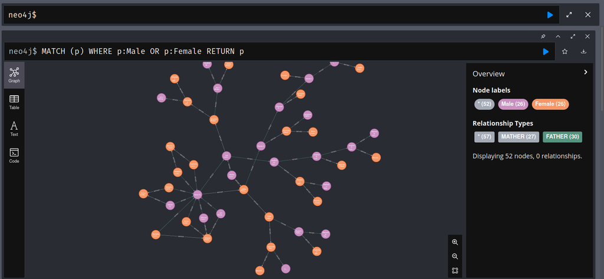

Interní je však repesentace pomocí JSON struktury:

```
{
    "p": {
"identity": 0,
"labels": [
        "Male"
      ],
"properties": {
"name": "Karel IV.",
"id": 1
      }
    }
  },
  {
    "p": {
"identity": 1,
"labels": [
        "Male"
      ],
"properties": {
"name": "Jan Lucemburský",
"id": 2
      }
    }
  },
  {
    "p": {
"identity": 2,
"labels": [
        "Female"
      ],
"properties": {
"name": "Eliška Přemyslovna",
"id": 3
      }
    }
  }, ...
```

## Využití cest v dotazech

Skutečná síla Cypher dotazů však leží ve využití cest tj. posloupnosti uzlů a vztahů. Pro příklad uveďme dotaz na jména všech předků Karla IV., kteří vládli Čechám.

```
MATCH ({name:"Karel IV."}) -[:FATHER|MOTHER*]-> (p) -[:RULES]-> (t:Territory)
WHERE t.name = "Čechy"
RETURN p.name
```

sekce `MATCH` začíná kotevním/počátečním bodem tj. uzlem, jehož vlastnost `name` je Karel IV. (to není úplně košer. lepší by bylo `(:Male {name:"Karel IV."})` (ale zde nehrozí, že by stejné jméno měla žena nebo dokonce teritorium). Z tohoto uzlu musí vést cesta přes libovolný počet vztahů `MOTHER` nebo `FATHER` do cílových uzlů (budou odkazovány symbolem `p`). Tyto uzly tedy representují všechny předky (samozřejmě jen ty co máme v databázi). Z těchto uzlů zároveň musí vycházet vztah `RULES` mířící do uzlu representujícího Čechy (v `MATCH` je pouze podmínka, že míří do nějakého teritoria, omezení na Čechy přináší sekce `WHERE`).

Výsledkem je následující tabulka:

```
╒════════════════════╕
│"p.name"            │
╞════════════════════╡
│"Vladislav I."      │
├────────────────────┤
│"Vratislav II."     │
├────────────────────┤
│"Břetislav I."      │
├────────────────────┤
│"Vladislav II"      │
├────────────────────┤
│"Přemysl Otakar I." │
├────────────────────┤
│"Václav I."         │
├────────────────────┤
│"Přemysl Otakar II."│
├────────────────────┤
│"Václav II."        │
├────────────────────┤
│"Jan Lucemburský"   │
└────────────────────┘
```

Výsledek lze samozřejmě i třídit.

```
MATCH (s {name:"Karel IV."}) -[:FATHER|MOTHER*]-> (p) -[:RULES]-> (t:Territory)
   WHERE t.name = "Čechy"
   RETURN p.name
   ORDER BY p.name
```

Jak ale ukazuje má řazení českých znaků k dokonalosti daleko.

```
╒════════════════════╕
│"p.name"            │
╞════════════════════╡
│"Břetislav I."      │
├────────────────────┤
│"Jan Lucemburský"   │
├────────────────────┤
│"Přemysl Otakar I." │
├────────────────────┤
│"Přemysl Otakar II."│
├────────────────────┤
│"Vladislav I."      │
├────────────────────┤
│"Vladislav II"      │
├────────────────────┤
│"Vratislav II."     │
├────────────────────┤
│"Václav I."         │
├────────────────────┤
│"Václav II."        │
└────────────────────┘
```

> **Úkol**: Vytvořte dotaz, který najde všechy, ženy u nichž známe alespoň jednoho dědečka.

Dotaz: TUFUQ0ggKGY6RmVtYWxlKS1bOkZBVEhFUnw6TUFUSEVSXS0+KCktWzpGQVRIRVJdLT4oKSBSRVRVUk4gZg==

V dotazech lze využívat i seskupování a to prostřednictvím standardní klauzule `RETURN`. Lze tak například zjistit, čemu vládli jednotliví mužové.

```
MATCH (m:Male)-[:RULES]->(n) RETURN m, collect(n.name)
```

Funkce `collect` spojuje všechny vázané hodnoty do jednotlivého pole.

Výsledkem je následující seznam:

```
╒═════════════════════════════════════════════╤═════════════════════════════╕
│"m"                                          │"collect(n.name)"            │
╞═════════════════════════════════════════════╪═════════════════════════════╡
│{"name":"Karel IV.","id":1}                  │["SŘŘ","Lucembursko","Čechy"]│
├─────────────────────────────────────────────┼─────────────────────────────┤
│{"name":"Jan Lucemburský","id":2}            │["Lucembursko","Čechy"]      │
├─────────────────────────────────────────────┼─────────────────────────────┤
│{"name":"Jindřich VII. Lucemburský","id":4}  │["SŘŘ","Lucembursko"]        │
├─────────────────────────────────────────────┼─────────────────────────────┤
│{"name":"Václav II.","id":6}                 │["Čechy"]                    │
├─────────────────────────────────────────────┼─────────────────────────────┤
│{"name":"Jindřich VI. Lucemburský","id":8}   │["Lucembursko"]              │
├─────────────────────────────────────────────┼─────────────────────────────┤
│{"name":"Jan I. Brabantský","id":10}         │["Limburg","Brabantsko"]     │
├─────────────────────────────────────────────┼─────────────────────────────┤
│{"name":"Přemysl Otakar II.","id":12}        │["Rakousko","Čechy"]         │
├─────────────────────────────────────────────┼─────────────────────────────┤
│{"name":"Rudolf I. Habsburský","id":14}      │["Rakousko","SŘŘ"]           │
├─────────────────────────────────────────────┼─────────────────────────────┤
│{"name":"Jindřich V. Lucemburský","id":16}   │["Lucembursko"]              │
├─────────────────────────────────────────────┼─────────────────────────────┤
│{"name":"Přemysl Otakar I.","id":48}         │["Čechy"]                    │
├─────────────────────────────────────────────┼─────────────────────────────┤
│{"name":"Vladislav II","id":96}              │["Čechy"]                    │
├─────────────────────────────────────────────┼─────────────────────────────┤
│{"name":"Jindřich III. Brabantský","id":20}  │["Lotrinsko","Brabantsko"]   │
├─────────────────────────────────────────────┼─────────────────────────────┤
│{"name":"Vít z Dampierre","id":22}           │["Namur","Flandry"]          │
├─────────────────────────────────────────────┼─────────────────────────────┤
│{"name":"Václav IV.","id":114}               │["SŘŘ","Čechy"]              │
├─────────────────────────────────────────────┼─────────────────────────────┤
│{"name":"Václav I.","id":24}                 │["Čechy"]                    │
├─────────────────────────────────────────────┼─────────────────────────────┤
│{"name":"Rostislav Haličský","id":26}        │["Slavonsko"]                │
├─────────────────────────────────────────────┼─────────────────────────────┤
│{"name":"Zikmud Lucemburský","id":124}       │["Uhry","SŘŘ","Čechy"]       │
├─────────────────────────────────────────────┼─────────────────────────────┤
│{"name":"Jan Zhořelecký","id":126}           │["Braniborsko"]              │
├─────────────────────────────────────────────┼─────────────────────────────┤
│{"name":"Albrecht IV. Habsburský","id":28}   │["Horní Alsasko","Aargau"]   │
├─────────────────────────────────────────────┼─────────────────────────────┤
│{"name":"Walram III. Limburský","id":32}     │["Limburg","Lucembursko"]    │
├─────────────────────────────────────────────┼─────────────────────────────┤
│{"name":"Vladislav I.","id":200}             │["Čechy"]                    │
├─────────────────────────────────────────────┼─────────────────────────────┤
│{"name":"Vratislav II.","id":202}            │["Čechy"]                    │
├─────────────────────────────────────────────┼─────────────────────────────┤
│{"name":"Břetislav I.","id":204}             │["Čechy"]                    │
├─────────────────────────────────────────────┼─────────────────────────────┤
│{"name":"Václav Lucemburský","id":300}       │["Lucembursko"]              │
└─────────────────────────────────────────────┴─────────────────────────────┘
```

Jak lze vidět tak většina mužských předků vládla alespoň jedné zemi. Existují však i předci, kteří se museli spokojit se šlechtictvím. Dotaz nám to neřekne, neboť `MATCH` vrací jen ty cesty, které úplně odpovídají vzoru.

Cypher však podporuje jen i klauzuli `OPTIONAL MATCH`, která uspěje i když se s ničím neshoduje a v tomto případě vrací prázdný seznam či null. Použitím odpovídá operátoru *outer join* z SQL.

```
MATCH (m:Male)
OPTIONAL MATCH (m)-[:RULES]->(n)
RETURN m,collect(n.name)
```

Z výsledku je zřejmé, že v naší geneologické databázi existují dva nezeměpanští muži. Zkusíme si vypsat jejich jména.

```
MATCH (m:Male)
OPTIONAL MATCH (m)-[:RULES]->(n)
  WITH m,collect(n.name) AS ts
  WHERE size(ts) = 0
  RETURN m.name
```

```
╒════════════════════════════╕
│"m.name"                    │
╞════════════════════════════╡
│"Balduin z Avesnes"         │
├────────────────────────────┤
│"Burkhard III. z Hohenbergu"│
└────────────────────────────┘
```

Novinkou je zde využití klauzule `WITH`. Ta má v tomto případě funkci podobnou `RETURN`. Místo vracení výsledku (= obdoba SQL selekce) však jen vytváří proměnné pro další fázi zpracování (tj. zároveň slouží jako zdroj tj. je to obdoba `MATCH`). Obdobou je klauzule `into` v Linq.

**Úkol**: Spočítejte průměrný počet zemí, jenž ovládá muž z naší databáze (se započtením i těch, co neovládají žádnou).

Výsledek: 1,46 (to není špatné a to jsem uváděl jen některé).

Dotaz: TUFUQ0ggKG06TWFsZSkgT1BUSU9OQUwgTUFUQ0ggKG0pLVs6UlVMRVNdLT4obikgV0lUSCBtLGNvbGxlY3Qobi5uYW1lKSBhcyB0cyBSRVRVUk4gYXZnKHNpemUodHMpKQ==

Výsledky dotazů mohou být i cesty. To lze využít například pro zjišťování minimální vzdálenosti, tj. v našem příkladě vzdáleností v pokrevní linii. Tato vzdálenost je 1 pro rodiče dané osoby stejně jako pro její děti (2 pro prarodiče, vnuky a sourozence).

Dotaz má následující tvar:

```
MATCH path=(:Male {name:"Karel IV."}) -[:FATHER|MOTHER*1..9]- (n)
   WITH  n, length(path) as lpath
   RETURN n.name, min(lpath) as mlpath
   ORDER BY  mlpath
```

V sekci `MATCH` najdeme všechny cesty od Karla IV do ostatních uzlů representující osoby (to nemusíme explicite uvádět, neboť jen ty jsou dosažitelné vztahem matka a otec).

Všimněte si dvou nových konstrukcí. Za prvé vztahy jsou nyní procházeny v obou směrech (vzor má podobu `-[]-` nikoliv `-[]->`) a za druhé zápis `*1..9` označuje, že v cestě musí být 1 až devět hran (vztahů).

> **Poznámka**: v terminologii teorie grafů se jedná o **tah** tj. mohou se v něm opakovat uzly ale nikoliv hrany, zde využívám terminologii *Cypheru*

Konstrukce MATCH tak nejde všechny všechny cesty (tahy) o délce 1 až 9 začínající ve startovním uzlu a tyto cesty označí identifikátorem `path` (koncové uzly pak identifikátorem `n`).

V klazuli `WITH` se pak vyprodukují dvojice koncový uzel a délka cesty (pro každou cestu ke každému uzlu). V sekci `RETURN` se pak provede seskupení podle koncového uzlu, pro nějž se najde nejkratší délka.

> **Otázka:** V Cypher neexistuje obdoba konstrukce `GROUP BY`. Co ji nahrazuje?

Poslední klazule setřídí uzly podle délky minimálních cest (vzestupně).

Výsledek (vyzkoušejte) odpovídá očekávání. Je zde však jeden problém -- i když je graf relativně jednoduchý a obahuje jen málo (neorientovaných) cyklů je počet existujících tahů do každého z uzlů překvapivě vysoký (jednotlivé cykly se dají různě kombinovat).

Počet tahů pro jejich různé délky ukazuje následující graf. Je zřejmé, že je shora omezen (na rozdíl od počtu sledů), ale pro delší tahy je přes 200 000.

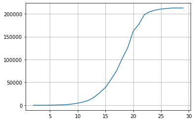

```python
import matplotlib.pyplot as plt

x = range(2, 30)
y = [24, 50, 88, 244, 470, 795, 1310, 2656, 4609, 7058, 11010, 17954, 27954, 38978, 56642, 75330,
     101954, 125698, 161986, 176962, 198274, 204610, 208066, 210370, 211522, 212674, 212674, 212674]
plt.plot(x, y)
plt.grid(True)
```

> **Úkol**: Jakým dotazem lze zjistit počet cest?

Z tohoto důvodu je vyhledávání omezeno na cesty délky maximálně 9 (což je vzdálenost k nejvzdálenějšímu pokrevnímu příbuznému v našem grafu). Toto řešení však příliš nepomůže u složitějších grafů (tj. např. pokud bychom do našeho grafu přidali i další potomky předků).

Proto je nutné zvolit jiné řešení. Nejdříve se však podíváme na další klíčový mechanismus.

## Nastavování atributů na základě komplexnějších dotazů

```
MATCH ({name: "Václav IV."}) -[:FATHER|MOTHER]-> () <-[:FATHER|MOTHER]- (s)
RETURN s
```

Výsledek dotazu můžeme využít pro nastavení atributu `relation` u nalezených uzlů.

```
MATCH ({name: "Václav IV."}) -[:FATHER|MOTHER]-> () <-[:FATHER|MOTHER]- (s)
SET s.relation="sibling"
```

Nyní lze pro nalezení sourozenců použít jednodušší dotaz:

```
MATCH (n) WHERE n.relation = "sibling"
RETURN n
```

A především lze využít dotaz využít jako východisko dalších dotazů.

```
MATCH (v {name:"Václav IV."}), (v) -[:FATHER]-> () <-[:FATHER]- (fs),  (v) -[:MOTHER]-> () <-[:MOTHER]- (ms)
WHERE fs = ms
RETURN fs
```

> **Otázka**: Co je výsledkem dotazu?

Nyní již jistě víte, jak dosáhnout efektivnějšího zjištění stupně přímého příbuzenství. K tomu však potřebujeme postupné provedení několika modifikujících dotazů. Cypher je však deklarativní jazyk a tudíž v něm nelze (stejně jako v SQL) zajistit postupné volání několika modifikujích dotazů v cyklu. Konstrukce `FOREACH` resp. `UNWIND` umožňuje provedení několika dotazů s různými hodnotami, ale ty se vykonávájí všechny najednou tj. jako by byly vykonány paralelně (pro skutečný paralelismus je nutný distribuovaný systém, ale výsledek na tom nezávisí).

> **Úkol**: Prostudujte konstrukce `FOREACH` a `UNWIND` (https://neo4j.com/docs/cypher-manual/current/) a jejich použití. Čím se liší a co mají společné?

Proto musíme využít nějakou procedurální nadstavbu Cypheru. Z více možností zvolíme možnost aktivace Cypher dotazů z Pythonu.

## Python a Neo4j

Python je primárně podporován tzv. ovladačem `neo4j-driver`, což je nízkoúrovňový modul, který zajištuje komunikaci s DBMS. Při využití ovladače je kód blízký kódu v jiných jazycích (primární jazyk je Java).

Pro snadnější a více pythonické rozhraní je možno použít nadstavbových knihoven. Zde budeme využívat modul `py2neo`, který podporuje i nejnovější verze databázového systému.

Modul podporuje snadné vykonávání Cypher příkazů, mapuje Cypher objekty do pythonských.

```python
from py2neo import Graph

g = Graph("bolt://localhost:7687", auth=("neo4j", "test"), name="neo4j") #| připojení a vytvoření objektu
c = g.run("MATCH (n:Male) WHERE left(n.name, 1)='V' RETURN n")
for record in c:
    print(record)
```

```
Node('Male', id=6, name='Václav II.')
Node('Male', id=96, name='Vladislav II')
Node('Male', id=22, name='Vít z Dampierre')
Node('Male', id=114, name='Václav IV.')
Node('Male', id=24, name='Václav I.')
Node('Male', id=200, name='Vladislav I.')
Node('Male', id=202, name='Vratislav II.')
Node('Male', id=300, name='Václav Lucemburský')
```

Kontruktor třídy `Graph` vytváří objekt zapouzdřující databázi se jménem `name` na serveru určeném URL, kde uživatele a heslo určuje parametr `auth`.

Metoda `run` provede Cypher příkaz a vrátí kurzor. Ten jen iterovatelný a jednotlivé iterace tvoří záznamy.

```python
for record in g.run("MATCH () -[r:FATHER]-> (m) RETURN m, r"):
    print(record[1].end_node["name"])
```

```
Jan Lucemburský
Jindřich VII. Lucemburský
Václav II.
Jindřich VI. Lucemburský
Jan I. Brabantský
Přemysl Otakar II.
Rudolf I. Habsburský
Jindřich V. Lucemburský
Balduin z Avesnes
Jindřich III. Brabantský
Vít z Dampierre
Václav I.
Rostislav Haličský
Albrecht IV. Habsburský
Burkhard III. z Hohenbergu
Walram III. Limburský
Vladislav II
Vladislav I.
Karel IV.
Karel IV.
Karel IV.
Karel IV.
Přemysl Otakar I.
Karel IV.
Karel IV.
Karel IV.
Karel IV.
Vratislav II.
Břetislav I.
Jan Lucemburský
```

> **Otázka**: Co vrátil Cypher příkaz (tj. co representuje každý záznam). Co bylo ze záznamu extrahováno a jak?

Kromě metody `run` lze vyžít u metodu `update` pokud není očekán žádná výstup resp. `evaluate`, pokud ve výstupu očekáváme jeden skalár.

Nyní už můžeme implementovat efektivnější algoritmus pro získání délky minimální cesty mezi uzly. Nejdříve u všech uzlů vytvoříme vlastnost `distance`, která bude mít hodnotu -1 (značí dosud nenavštívený uzel). Pak u startovního uzlu změníme tuto distanci na nulu.

```python
g.update("MATCH (s) WHERE s:Male or s:Female SET s.distance=-1")
g.update("MATCH (s {name: 'Karel IV.'}) SET s.distance=0")
```

Nyní budeme v cyklu postupně označovat uzly se vzdáleností 1 (= sousedé počátečního), 2, atd. Skončíme až nezbudou žádné neoznačené uzly (tj. uzly s `distance`=-1). Jádrem je nalezení (`MATCH`) uzlů, do nichž vedou hrany `FATHER` nebo `MOTHER` z uzlů s danou vzdálenost. Ty pak získají vzdálenost o jedničku vyšší.

```python
dist = 0
while s:=g.evaluate("MATCH (n {distance:-1}) RETURN count(n)"):
    print(s)
    g.update(f"MATCH (m {{distance: {dist}}}) -[:FATHER|MOTHER]-  (n {{distance:-1}}) SET n.distance=m.distance + 1")
    dist +=1
```

```
51
41
33
25
9
5
3
2
1
```

Nakonec vypíšeme výsledek (pro přehlednost jej převedeme do pandas datarámce).

```python
import pandas as pd

result = g.run("MATCH (m) WHERE exists(m.distance) RETURN m.name, m.distance ORDER BY m.distance, m.name")
pd.DataFrame(result, columns =['Name', 'Distance'])
```

|  | Name | Distance |
| --- | --- | --- |
| 0 | Karel IV. | 0 |
| 1 | Alžběta Lucemburská | 1 |
| 2 | Anna Lucemburská | 1 |
| 3 | Eliška Přemyslovna | 1 |
| 4 | Jan Lucemburský | 1 |
| 5 | Jan Zhořelecký | 1 |
| 6 | Kateřina Lucemburská | 1 |
| 7 | Markéta Lucemburská | 1 |
| 8 | Markéta Lucemburská | 1 |
| 9 | Václav IV. | 1 |
| 10 | Zikmud Lucemburský | 1 |
| 11 | Alžbeta Pomořanská | 2 |
| 12 | Anna Svídnická | 2 |
| 13 | Blanka z Valois | 2 |
| 14 | Guta Habsburská | 2 |
| 15 | Jindřich VII. Lucemburský | 2 |
| 16 | Markéta Brabantská | 2 |
| 17 | Václav II. | 2 |
| 18 | Václav Lucemburský | 2 |
| 19 | Beatrix z Avesnes | 3 |
| 20 | Gertruda z Hohenbergu | 3 |
| 21 | Jan I. Brabantský | 3 |
| 22 | Jindřich VI. Lucemburský | 3 |
| 23 | Kunhuta Uherská]] | 3 |
| 24 | Markéta z Dampierre | 3 |
| 25 | Přemysl Otakar II. | 3 |
| 26 | Rudolf I. Habsburský | 3 |
| 27 | Adéla Burgundská | 4 |
| 28 | Albrecht IV. Habsburský | 4 |
| 29 | Anna Uherská | 4 |
| 30 | Balduin z Avesnes | 4 |
| 31 | Burkhard III. z Hohenbergu | 4 |
| 32 | Felicita z Coucy | 4 |
| 33 | Hedvika z Kyburgu | 4 |
| 34 | Jindřich III. Brabantský | 4 |
| 35 | Jindřich V. Lucemburský | 4 |
| 36 | Kunhuta Štaufská | 4 |
| 37 | Markéta z Baru | 4 |
| 38 | Matylda z Béthuné | 4 |
| 39 | Mechtilda z Tübingenu | 4 |
| 40 | Rostislav Haličský | 4 |
| 41 | Václav I. | 4 |
| 42 | Vít z Dampierre | 4 |
| 43 | Ermesinda Lucemburská | 5 |
| 44 | Konstancie Uherská | 5 |
| 45 | Přemysl Otakar I. | 5 |
| 46 | Walram III. Limburský | 5 |
| 47 | Judita Durynská | 6 |
| 48 | Vladislav II | 6 |
| 49 | Vladislav I. | 7 |
| 50 | Vratislav II. | 8 |
| 51 | Břetislav I. | 9 |

> **Úkol**: Výše uvedený algoritmus funguje jen pro souvislé grafy. Pozměňte ho tak, aby toto omezení neměl.

### Programové vytváření grafu

Programové vytváření grafu si ukážeme na ukládání hierarchického souboru, jenž je vytvářen příkazem `lshw --json` (samozřejmě v Linuxu, používání jiného OS si nedovedu představit)

Tento JSON soubor má jednoduchou strukturu, každé zařízení je určeno několika atributy a podřízená zařízení jsou soustředěna v poli se jménem `children`.

Klíčovou roli při vytváření hraje objekt representujíci transakci (proměnná `tx`). Je vytvořen voláním metody `begin` nad objektem grafu. Uzly a vztahy se přidávají metodou `create`. A no konci je nutno zavolat metodu `commit` (jinak se změny neprojeví).

```python
import json
from py2neo import Node, Relationship

def process_device(tree, parentNode, tx):
    id = tree["id"] # jedinečné id zařízení
    cls = tree["class"] # třída zařízení
    desc = f"{tree.get('description','')}:{tree.get('product','')}" # jméno zařízení (ne zcela obecné řešení)
    capacity = int(tree.get("capacity", 0)) # kapacita zařízení v bytech

    # creation of node
    node = Node(cls, desc=desc, capacity=capacity) # popisek třídy zařízení
    node.add_label("device") # společný popisek
    tx.create(node)

    # creation of Relationship
    if parentNode:
        rs = Relationship(node, "PARENT", parentNode)
        tx.create(rs)

    if "children" in tree:
        for child in tree["children"]:
            process_device(child, node, tx)

with open("lshw") as f:
    tree = json.load(f)
    tx =  g.begin() # create context (= )
    process_device(tree[0], None, tx)
    tx.commit()
```